# Choosing MGB Biobank asthmatic subject/sample numbers for further omics study

Diagnosis, BMI, smoking, lab tests

MHuang

2/8/2021

# 1. Subject selection pool & diagnosis data

```r
pool <- fread(pool_fname); nrow(pool)
```

```
## [1] 8766
```

```r
pool[, last_plasma_date := as.Date(last_plasma_date, format = "%Y-%m-%d")]

dia <- fread(str_c(rpdr_file_header, "Dia", rpdr_file_ending), quote = "")
dia[, unique(EMPI)] %in% pool[, EMPI] %>% table()
```

```
## .
## FALSE  TRUE
##  9007  8766
```

```r
dia <- dia[EMPI %in% pool$EMPI, ] # Restrict to subjects in selection pool

dia[, Date := as.Date(Date, format = "%m/%d/%Y")]
dia[, summary(Date)]
```

```
##         Min.      1st Qu.       Median         Mean      3rd Qu.         Max.
## "1979-10-12" "2011-11-30" "2016-02-26" "2014-05-17" "2018-05-04" "2020-05-18"
```

```r
dia <- merge(dia, pool[, .(EMPI, last_plasma_date)], by = "EMPI", all.x = T)
dia[, dia_timegap_d := as.numeric(Date - last_plasma_date)][, dia_timegap_y := dia_timegap_d/365.25]
dia[, summary(dia_timegap_y)]
```

```
##     Min.  1st Qu.   Median     Mean  3rd Qu.     Max.
## -38.8720  -4.0931  -0.2218  -1.5788   2.0479   9.7194
```

```r
dia_condensed <- unique(dia[, .(Diagnosis_Name, Code_Type, Code)])
```

# 2. Asthma exacerbations & severity, adrenal insufficiency

Variable names:

- n_exac_dia: number of asthma exacerbation diagnoses
- has_exac_dia: has asthma exacerbation diagnoses
- n_sevr_dia: number of asthma severity diagnoses
- has_sevr_dia: has asthma severity diagnoses
- n_adrinsuf_dia: number of adrenal insufficiency diagnoses
- has_adrinsuf_dia: has drenal insufficiency diagnoses

Suffix:

- _1ybflastpl: within 1 year prior to last plasma date
- _2ybflastpl: within 2 years prior to last plasma date
- _3ybflastpl: within 3 years prior to last plasma date
- _4ybflastpl: within 4 years prior to last plasma date
- _5ybflastpl: within 5 years prior to last plasma date

## 2.1. Exacerbation counts

> Status asthmaticus is a medical emergency, an extreme form of asthma exacerbation characterized by hypoxemia, hypercarbia, and secondary respiratory failure (Ref: [NCBI Book](https://www.ncbi.nlm.nih.gov/books/NBK526070/)).

```r
dia_condensed[grep("asthma", Diagnosis_Name, ignore.case = T),
              ][grep("exacer|asthmaticus", Diagnosis_Name, ignore.case = T), ] %>% datatable()
```

|  | Diagnosis_Name | Code_Type | Code |
| --- | --- | --- | --- |
| 1 | Asthma, unspecified without mention of status asthmaticus | ICD9 | 493.90 |
| 2 | Chronic obstructive asthma, without mention of status asthmaticus | ICD9 | 493.20 |
| 3 | Asthma, unspecified type, with acute exacerbation | ICD9 | 493.92 |
| 4 | Extrinsic asthma without mention of status asthmaticus | ICD9 | 493.00 |
| 5 | Unspecified asthma with (acute) exacerbation | ICD10 | J45.901 |
| 6 | Chronic obstructive asthma with acute exacerbation | ICD9 | 493.22 |
| 7 | Asthma, unspecified type, with status asthmaticus | ICD9 | 493.91 |
| 8 | Intrinsic asthma, with acute exacerbation | ICD9 | 493.12 |
| 9 | Severe persistent asthma with (acute) exacerbation | ICD10 | J45.51 |
| 10 | Intrinsic asthma without mention of status asthmaticus | ICD9 | 493.10 |

[output cut: 13 more lines]

```r
asth_exac <- dia[grep("asthma", Diagnosis_Name, ignore.case = T),
                 ][grep("exacer|with status asthmaticus", Diagnosis_Name, ignore.case = T), ]


## There may be multiple records for the same person on the same day

asth_exac <- unique(asth_exac[, .(EMPI, Date, Diagnosis_Name, Code_Type, Code,
                                  last_plasma_date, dia_timegap_d, dia_timegap_y)])
```

## 2.2. Severity recorded ever

> Severity classification only associated with ICD10 codes

```r
dia_condensed[grep("asthma", Diagnosis_Name, ignore.case = T), ] %>% datatable()
```

|  | Diagnosis_Name | Code_Type | Code |
| --- | --- | --- | --- |
| 1 | Asthma, unspecified without mention of status asthmaticus | ICD9 | 493.90 |
| 2 | Chronic obstructive asthma, without mention of status asthmaticus | ICD9 | 493.20 |
| 3 | Asthma, unspecified type, with acute exacerbation | ICD9 | 493.92 |
| 4 | Extrinsic asthma without mention of status asthmaticus | ICD9 | 493.00 |
| 5 | Unspecified asthma, uncomplicated | ICD10 | J45.909 |
| 6 | Mild intermittent asthma, uncomplicated | ICD10 | J45.20 |
| 7 | Unspecified asthma with (acute) exacerbation | ICD10 | J45.901 |
| 8 | Mild persistent asthma, uncomplicated | ICD10 | J45.30 |
| 9 | Asthma-LMR 29 | LMR | LPA29 |
| 10 | Chronic obstructive asthma with acute exacerbation | ICD9 | 493.22 |

[output cut: 48 more lines]

```r
asth_sevr <- dia[grepl("Mild intermittent asthma|Mild persistent asthma, uncomplicated|
                       Moderate persistent asthma|Severe persistent asthma", Diagnosis_Name), ]
asth_sevr[, summary(Date)]
```

```
##         Min.      1st Qu.       Median         Mean      3rd Qu.         Max.
## "2015-09-30" "2017-03-01" "2018-03-22" "2018-03-08" "2019-03-26" "2020-05-15"
```

```r
## There may be multiple records for the same person on the same day

asth_sevr <- unique(asth_sevr[, .(EMPI, Date, Diagnosis_Name, Code_Type, Code,
                                  last_plasma_date, dia_timegap_d, dia_timegap_y)])
```

## 2.3. Adrenal insufficiency diagnosis

> Mineralocorticoid deficiency = hypoaldosteronism? Congenital adrenogenital disorders associated with enzyme deficiency removed (3 unique subjects excluded)

```r
dia_condensed[grep("insuffic|defic", Diagnosis_Name, ignore.case = T),
              ][grep("adren|cortic", Diagnosis_Name, ignore.case = T), ] %>% datatable()
```

|  | Diagnosis_Name | Code_Type | Code |
| --- | --- | --- | --- |
| 1 | Glucocorticoid deficiency | ICD9 | 255.41 |
| 2 | Unspecified adrenocortical insufficiency | ICD10 | E27.40 |
| 3 | Adrenal insufficiency-LMR 898 | LMR | LPA898 |
| 4 | Other adrenocortical insufficiency | ICD10 | E27.49 |
| 5 | Drug-induced adrenocortical insufficiency | ICD10 | E27.3 |
| 6 | Corticoadrenal insufficiency | ICD9 | 255.4 |
| 7 | Primary adrenocortical insufficiency | ICD10 | E27.1 |
| 8 | Adrenal insufficiency-Oncall | Oncall | ELAL3 |
| 9 | Mineralocorticoid deficiency | ICD9 | 255.42 |
| 10 | Congenital adrenogenital disorders associated with enzyme deficiency | ICD10 | E25.0 |

```r
adrenal_insuf <- dia[grep("insuffic|defic", Diagnosis_Name, ignore.case = T),
                     ][grep("adren|cortic", Diagnosis_Name, ignore.case = T),
                       ][!grepl("congenital", Diagnosis_Name, ignore.case = T), ]


## There may be multiple records for the same person on the same day

adrenal_insuf <- unique(adrenal_insuf[, .(EMPI, Date, Diagnosis_Name, Code_Type, Code,
                                          last_plasma_date, dia_timegap_d, dia_timegap_y)])


## Remove dia object to free up memory

rm(dia); gc()
```

```
##            used  (Mb) gc trigger   (Mb)  max used   (Mb)
## Ncells  1120445  59.9    7916164  422.8   6899097  368.5
## Vcells 86203454 657.7  415231470 3168.0 519039337 3960.0
```

## 2.4. Variables within time frame relative to last plasma date

```r
## Function to generate variables on sevrerbation diagnoses counts under certain restriction

dia_vars_fnc <- function(restriction, varname_suffix) {

        ## Exacerbations

        exac_tmp <- eval(parse(text = str_c("asth_exac[", restriction, ", ]")))
        exac_per_subj <- exac_tmp[, .(n_exac_dia = .N), EMPI]
        setnames(exac_per_subj, c("EMPI", str_c(colnames(exac_per_subj)[-1], varname_suffix)))
        pool <- merge(pool, exac_per_subj, by = "EMPI", all.x = T)
        eval(parse(text = str_c("pool[, ':='(has_exac_dia", varname_suffix, " = ifelse(!is.na(n_exac_dia",
                                             varname_suffix, "), 1, 0) %>% as.factor())]")))

        ## Severity

        sevr_tmp <- eval(parse(text = str_c("asth_sevr[", restriction, ", ]")))
        sevr_per_subj <- sevr_tmp[, .(n_sevr_dia = .N), EMPI]
        setnames(sevr_per_subj, c("EMPI", str_c(colnames(sevr_per_subj)[-1], varname_suffix)))
        pool <- merge(pool, sevr_per_subj, by = "EMPI", all.x = T)
        eval(parse(text = str_c("pool[, ':='(has_sevr_dia", varname_suffix, " = ifelse(!is.na(n_sevr_dia",
                                             varname_suffix, "), 1, 0) %>% as.factor())]")))

        ## Adrenal insufficiency

        adrinsuf_tmp <- eval(parse(text = str_c("adrenal_insuf[", restriction, ", ]")))
        adrinsuf_per_subj <- adrinsuf_tmp[, .(n_adrinsuf_dia = .N), EMPI]
        setnames(adrinsuf_per_subj, c("EMPI", str_c(colnames(adrinsuf_per_subj)[-1], varname_suffix)))
        pool <- merge(pool, adrinsuf_per_subj, by = "EMPI", all.x = T)
        eval(parse(text = str_c("pool[, ':='(has_adrinsuf_dia", varname_suffix, " = ifelse(!is.na(n_adrinsuf_dia",
                                             varname_suffix, "), 1, 0) %>% as.factor())]")))

        return(pool)
}

pool <- dia_vars_fnc(restriction = "", varname_suffix = "_alltime")
pool <- dia_vars_fnc(restriction = "dia_timegap_y <= 0", varname_suffix = "_bflastpl")
pool <- dia_vars_fnc(restriction = "dia_timegap_y <= 0 & dia_timegap_y >= -1", varname_suffix = "_1ybflastpl")
pool <- dia_vars_fnc(restriction = "dia_timegap_y <= 0 & dia_timegap_y >= -2", varname_suffix = "_2ybflastpl")
pool <- dia_vars_fnc(restriction = "dia_timegap_y <= 0 & dia_timegap_y >= -3", varname_suffix = "_3ybflastpl")
pool <- dia_vars_fnc(restriction = "dia_timegap_y <= 0 & dia_timegap_y >= -4", varname_suffix = "_4ybflastpl")
pool <- dia_vars_fnc(restriction = "dia_timegap_y <= 0 & dia_timegap_y >= -5", varname_suffix = "_5ybflastpl")
```

### 2.4.1. Compare exacerbation data in different time frames

```r
pool[, .N, .(has_exac_dia_1ybflastpl, has_exac_dia_3ybflastpl,
             has_exac_dia_5ybflastpl, has_exac_dia_bflastpl, has_exac_dia_alltime)
     ][order(has_exac_dia_1ybflastpl, has_exac_dia_3ybflastpl,
             has_exac_dia_5ybflastpl, has_exac_dia_bflastpl, has_exac_dia_alltime)] %>% datatable()
```

|  | has_exac_dia_1ybflastpl | has_exac_dia_3ybflastpl | has_exac_dia_5ybflastpl | has_exac_dia_bflastpl | has_exac_dia_alltime | N |
| --- | --- | --- | --- | --- | --- | --- |
| 1 | 0 | 0 | 0 | 0 | 0 | 6022 |
| 2 | 0 | 0 | 0 | 0 | 1 | 792 |
| 3 | 0 | 0 | 0 | 1 | 1 | 679 |
| 4 | 0 | 0 | 1 | 1 | 1 | 263 |
| 5 | 0 | 1 | 1 | 1 | 1 | 445 |
| 6 | 1 | 1 | 1 | 1 | 1 | 565 |

### 2.4.2. Compare severity availability in different time frames

```r
pool[, .N, .(has_sevr_dia_1ybflastpl, has_sevr_dia_3ybflastpl,
             has_sevr_dia_5ybflastpl, has_sevr_dia_bflastpl, has_sevr_dia_alltime)
     ][order(has_sevr_dia_1ybflastpl, has_sevr_dia_3ybflastpl,
             has_sevr_dia_5ybflastpl, has_sevr_dia_bflastpl, has_sevr_dia_alltime)] %>% datatable()
```

|  | has_sevr_dia_1ybflastpl | has_sevr_dia_3ybflastpl | has_sevr_dia_5ybflastpl | has_sevr_dia_bflastpl | has_sevr_dia_alltime | N |
| --- | --- | --- | --- | --- | --- | --- |
| 1 | 0 | 0 | 0 | 0 | 0 | 4631 |
| 2 | 0 | 0 | 0 | 0 | 1 | 2342 |
| 3 | 0 | 0 | 1 | 1 | 1 | 59 |
| 4 | 0 | 1 | 1 | 1 | 1 | 339 |
| 5 | 1 | 1 | 1 | 1 | 1 | 1395 |

### 2.4.3. Compare adrenal insufficiency data in different time frames

```r
pool[, .N, .(has_adrinsuf_dia_1ybflastpl, has_adrinsuf_dia_3ybflastpl,
             has_adrinsuf_dia_5ybflastpl, has_adrinsuf_dia_bflastpl, has_adrinsuf_dia_alltime)
     ][order(has_adrinsuf_dia_1ybflastpl, has_adrinsuf_dia_3ybflastpl,
             has_adrinsuf_dia_5ybflastpl, has_adrinsuf_dia_bflastpl, has_adrinsuf_dia_alltime)] %>% datatable()
```

|  | has_adrinsuf_dia_1ybflastpl | has_adrinsuf_dia_3ybflastpl | has_adrinsuf_dia_5ybflastpl | has_adrinsuf_dia_bflastpl | has_adrinsuf_dia_alltime | N |
| --- | --- | --- | --- | --- | --- | --- |
| 1 | 0 | 0 | 0 | 0 | 0 | 8460 |
| 2 | 0 | 0 | 0 | 0 | 1 | 115 |
| 3 | 0 | 0 | 0 | 1 | 1 | 47 |
| 4 | 0 | 0 | 1 | 1 | 1 | 24 |
| 5 | 0 | 1 | 1 | 1 | 1 | 26 |
| 6 | 1 | 1 | 1 | 1 | 1 | 94 |

# 3. Health history data

```r
phy <- fread(str_c(rpdr_file_header, "Phy", rpdr_file_ending))
phy[, unique(EMPI)] %in% pool[, EMPI] %>% table()
```

```
## .
## FALSE  TRUE
##  8772  8593
```

```r
phy <- phy[EMPI %in% pool$EMPI, ] # Restrict to subjects in selection pool


## Some general data check

phy[, .N, is.na(Date)]
```

```
##    is.na       N
## 1: FALSE 4271240
```

```r
phy[, Date := as.Date(Date, format = "%m/%d/%Y")]
phy[, summary(Date)]
```

```
##         Min.      1st Qu.       Median         Mean      3rd Qu.         Max.
## "1918-06-30" "2013-07-30" "2016-10-31" "2015-07-03" "2018-08-01" "2020-05-12"
```

```r
phy[, .N, Inpatient_Outpatient]
```

```
##    Inpatient_Outpatient       N
## 1:           Outpatient 4140233
## 2: Outpatient-Emergency   71696
## 3:            Inpatient   59311
```

```r
unique(phy[, .(Concept_Name, Code, Code_Type)]) %>% datatable(filter = "top")
```

|  | Concept_Name | Code | Code_Type |
| --- | --- | --- | --- |
| 1 | BMI | BMI | EPIC |
| 2 | Blood Pressure-Epic | BP | EPIC |
| 3 | Body Surface Area (BSA) | BSA | EPIC |
| 4 | Diastolic-Epic | DIABP | EPIC |
| 5 | Height | HGT | EPIC |
| 6 | Pain Score | PAINSCORE | EPIC |
| 7 | Pulse | PUL | EPIC |
| 8 | Alcohol User-Yes | SH-ALC-1 | EPIC |
| 9 | Alcohol User-Not Currently | SH-ALC-5 | EPIC |
| 10 | Alcohol Oz Per Week | SH-ALCOZWK | EPIC |

[output cut: 471 more lines]

```r
phy <- merge(phy, pool[, .(EMPI, last_plasma_date)], by = "EMPI", all.x = T)
```

## 3.1. BMI

Variable names:

- bmi: BMI value of a single record
- bmi_date: date of BMI record
- n_bmi_rec: number of BMI records
- bmi_all_values: list of all BMI values
- bmi_all_dates: list of all BMI record dates
- bmi_median: median BMI among all values
- bmi_min: minimum BMI among all values
- bmi_max: maximum BMI among all values
- bmi_mean: mean BMI averaged across all values

Suffix:

- _closest_lastpl: closest record to last plasma date
- _pm1y_lastpl: plus or minus 1 year around last plasma date
- _pm2y_lastpl: plus or minus 2 years around last plasma date
- _pm3y_lastpl: plus or minus 3 years around last plasma date

### 3.1.1. BMI closest to last plasma date

```r
phy[grepl("BMI", Concept_Name, ignore.case = T), .(Concept_Name, Code, Code_Type)] %>% unique()
```

```
##    Concept_Name Code Code_Type
## 1:          BMI  BMI      EPIC
## 2:          BMI
```

```r
bmi_long <- phy[grepl("BMI", Concept_Name, ignore.case = T), ]
bmi_long[, unique(EMPI)] %in% pool[, EMPI] %>% table()
```

```
## .
## TRUE
## 8213
```

```r
bmi_long[, .N, Units]
```

```
##    Units      N
## 1:       107723
## 2: kg/m2 159762
```

```r
bmi_long[, summary(as.numeric(Result))] # No missing
```

```
##    Min. 1st Qu.  Median    Mean 3rd Qu.    Max.
##    2.37   25.11   29.44   30.69   34.94 3259.98
```

```r
bmi_long[, ':='(bmi_timegap_d = as.numeric(Date - last_plasma_date),
                bmi = as.numeric(Result))][, ':='(bmi_timegap_y = bmi_timegap_d/365.25,
                                                  bmi_timegap_d_abs = abs(bmi_timegap_d))]
bmi_long[, summary(bmi_timegap_d)]
```

```
##    Min. 1st Qu.  Median    Mean 3rd Qu.    Max.
## -8994.0 -1630.0  -330.0  -633.4   520.0  3465.0
```

```r
bmi_long[order(-bmi)][1:100, bmi]
```

```
##   [1] 3259.98  331.85  297.29  294.09  269.30  257.83  250.15  248.97  248.97
##  [10]  248.03  224.05  205.72  200.76  197.54  190.57  182.18  178.99  176.85
##  [19]  157.93  153.72  151.55  149.94  148.12  143.88  132.74  100.56   99.50
##  [28]   98.32   97.02   96.19   95.77   94.51   93.64   93.37   93.26   93.26
##  [37]   92.77   92.00   90.71   90.71   89.90   89.26   89.05   88.92   88.24
##  [46]   86.42   86.15   85.74   85.50   85.00   84.79   84.56   84.51   84.49
##  [55]   84.44   84.19   84.10   83.96   83.93   83.72   83.72   83.60   82.58
##  [64]   82.41   81.78   81.54   81.52   81.49   81.18   81.11   81.11   81.11
##  [73]   80.89   80.66   80.55   79.89   79.76   79.76   79.58   79.42   78.79
##  [82]   78.79   78.78   78.54   78.50   78.11   77.72   77.67   77.31   77.20
##  [91]   77.03   76.75   76.62   76.16   76.11   75.99   75.59   75.55   75.28
## [100]   75.10
```

```r
bmi_long[order(bmi)][1:100, bmi]
```

```
##   [1]  2.37  3.68  3.84  3.93  6.84  7.49  8.07  8.17  8.38  8.39  8.48  8.67
##  [13]  8.84  9.08  9.25  9.62  9.76  9.88  9.97 10.04 10.12 10.17 10.18 10.21
##  [25] 10.26 10.35 10.41 10.46 10.49 10.57 10.65 10.65 10.65 10.65 10.65 10.81
##  [37] 10.82 10.82 11.12 11.34 11.34 11.46 11.48 11.72 11.81 11.86 11.86 11.91
##  [49] 11.98 12.14 12.34 12.44 12.52 12.80 12.88 12.88 12.88 12.89 12.96 13.01
##  [61] 13.03 13.07 13.09 13.23 13.31 13.31 13.32 13.38 13.38 13.38 13.40 13.40
##  [73] 13.41 13.42 13.44 13.46 13.48 13.50 13.50 13.55 13.56 13.58 13.61 13.61
##  [85] 13.62 13.64 13.64 13.68 13.70 13.73 13.78 13.78 13.78 13.81 13.85 13.85
##  [97] 13.87 13.88 13.96 13.97
```

```r
bmi_long <- bmi_long[bmi <= 99 & bmi >= 10, ]
# 10 & 99 are specific cutoffs for these data;
# from examination of patients records over time, those >99 / <10 are likely errors

setkey(bmi_long, EMPI, bmi_timegap_d_abs)
bmi_closest <- bmi_long[, head(.SD, 1), EMPI]
bmi_closest[, .N, .(`BMI_absolute_timegap=0d` = bmi_timegap_d_abs == 0,
                    `BMI_absolute_timegap<=7d` = bmi_timegap_d_abs <= 7,
                    `BMI_absolute_timegap<=1y` = abs(bmi_timegap_y) <= 1)]
```

```
##    BMI_absolute_timegap=0d BMI_absolute_timegap<=7d BMI_absolute_timegap<=1y
## 1:                   FALSE                    FALSE                     TRUE
## 2:                    TRUE                     TRUE                     TRUE
## 3:                   FALSE                     TRUE                     TRUE
## 4:                   FALSE                    FALSE                    FALSE
##       N
## 1: 3305
## 2: 3488
## 3:  679
## 4:  741
```

```r
setnames(bmi_closest, c("bmi", "Date", "Units"), str_c(c("bmi", "bmi_date", "bmi_unit"), "_closest_lastpl"))
tmp_cols <- c("EMPI", str_c(c("bmi", "bmi_date", "bmi_unit"), "_closest_lastpl"))
pool <- merge(pool, bmi_closest[, ..tmp_cols], by = "EMPI", all.x = T)
pool[, has_bmi_closest_lastpl := ifelse(!is.na(bmi_closest_lastpl), 1, 0) %>% as.factor()]

pool[, .N, has_bmi_closest_lastpl]
```

```
##    has_bmi_closest_lastpl    N
## 1:                      1 8213
## 2:                      0  553
```

```r
pool[, summary(bmi_closest_lastpl)]
```

```
##    Min. 1st Qu.  Median    Mean 3rd Qu.    Max.    NA's
##   12.88   24.51   28.46   29.67   33.64   92.77     553
```

```r
pool[, summary(as.numeric(bmi_date_closest_lastpl - last_plasma_date))]
```

```
##     Min.  1st Qu.   Median     Mean  3rd Qu.     Max.     NA's
## -5962.00    -8.00     0.00   -26.61     6.00  2971.00      553
```

### 3.1.2. BMI within (+/-)1 year of last plasma date

```r
## Function to generate variables on BMI under certain restriction

bmi_vars_fnc <- function(restriction, varname_suffix) {
        bmi_tmp <- eval(parse(text = str_c("bmi_long[", restriction, ", ]")))
        bmi_per_subj <- bmi_tmp[, .(n_bmi_rec = .N,
                                    bmi_all_values = str_c(bmi, collapse = ";"),
                                    bmi_all_dates = str_c(Date, collapse = ";"),
                                    bmi_median = median(bmi),
                                    bmi_min = min(bmi),
                                    bmi_max = max(bmi),
                                    bmi_mean = mean(bmi)), EMPI]
        bmi_per_subj <- eval(parse(text = str_c("merge(bmi_per_subj, bmi_closest[", restriction,
                                                ", .(EMPI, bmi_timegap_d)], by = 'EMPI', all.x = T)")))
        setnames(bmi_per_subj, "bmi_timegap_d", "bmi_closest_timegap_d")
        setnames(bmi_per_subj, c("EMPI", str_c(colnames(bmi_per_subj)[-1], varname_suffix)))
        pool <- merge(pool, bmi_per_subj, by = "EMPI", all.x = T)
        eval(parse(text = str_c("pool[, has_bmi_rec", varname_suffix,
                                " := ifelse(!is.na(n_bmi_rec", varname_suffix, "), 1, 0) %>% as.factor()]")))
        return(pool)
}


## Generate variables on BMI records from within (+/-)1 year of last plasma date

pool <- bmi_vars_fnc(restriction = "abs(bmi_timegap_y) <= 1", varname_suffix = "_pm1y_lastpl")


## Check median BMI from within (+/-)1 year against BMI closest to last plasma date

pool[, .N, .(has_bmi_closest_lastpl, has_bmi_rec_pm1y_lastpl)]
```

```
##    has_bmi_closest_lastpl has_bmi_rec_pm1y_lastpl    N
## 1:                      1                       1 7472
## 2:                      1                       0  741
## 3:                      0                       0  553
```

```r
pool[, summary(bmi_closest_timegap_d_pm1y_lastpl)]
```

```
##     Min.  1st Qu.   Median     Mean  3rd Qu.     Max.     NA's
## -364.000   -3.000    0.000   -1.025    3.000  365.000     1294
```

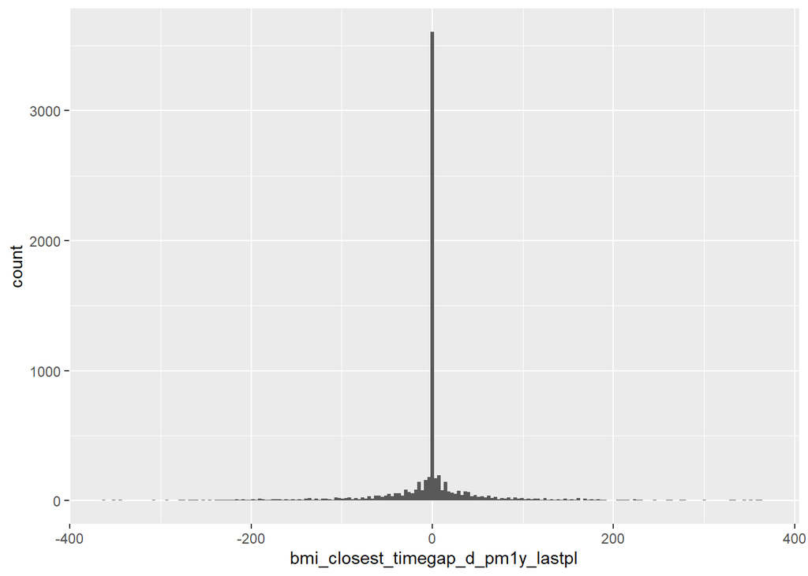

```r
ggplot(pool) + geom_histogram(aes(x = bmi_closest_timegap_d_pm1y_lastpl), bins = 200)
```

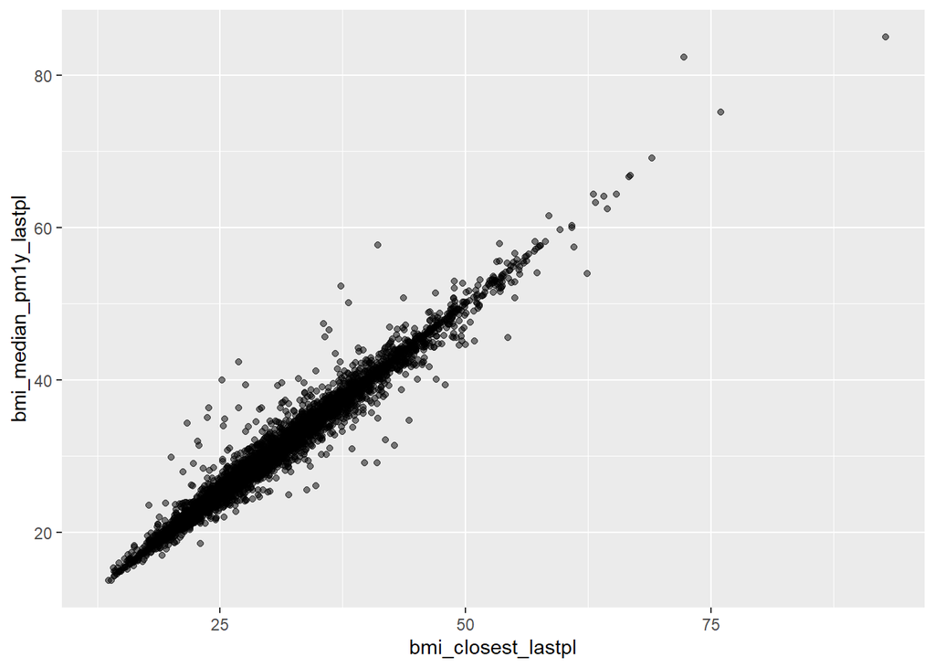

```r
ggplot(pool, aes(x = bmi_closest_lastpl, y = bmi_median_pm1y_lastpl)) +
        geom_point(alpha = 0.5)
```

### 3.1.3. BMI within (+/-)2 years of last plasma date

```r
## Generate variables on BMI records from within (+/-)2 years of last plasma date

pool <- bmi_vars_fnc(restriction = "abs(bmi_timegap_y) <= 2", varname_suffix = "_pm2y_lastpl")


## Check median BMI from within (+/-)2 years against BMI closest to last plasma date

pool[, .N, .(has_bmi_closest_lastpl, has_bmi_rec_pm2y_lastpl)]
```

```
##    has_bmi_closest_lastpl has_bmi_rec_pm2y_lastpl    N
## 1:                      1                       1 7836
## 2:                      1                       0  377
## 3:                      0                       0  553
```

```r
pool[, summary(bmi_closest_timegap_d_pm2y_lastpl)]
```

```
##      Min.   1st Qu.    Median      Mean   3rd Qu.      Max.      NA's
## -728.0000   -5.0000    0.0000   -0.4661    5.0000  728.0000       930
```

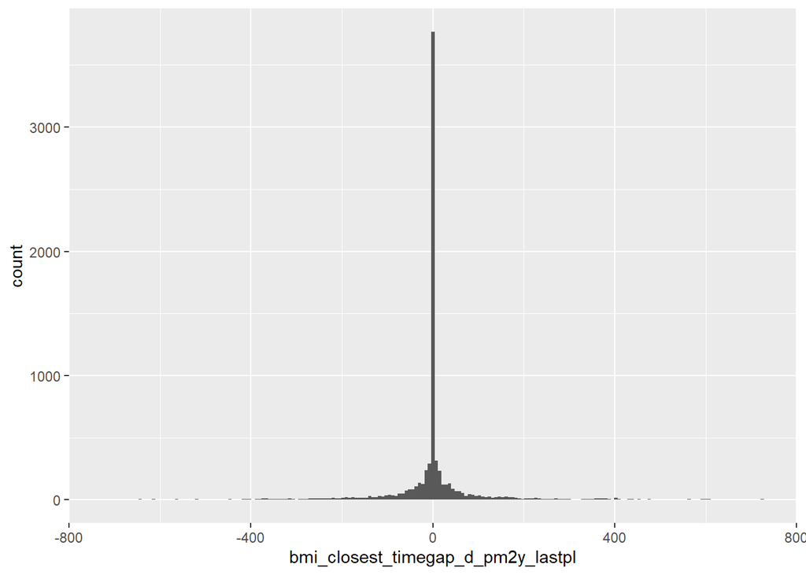

```r
ggplot(pool) + geom_histogram(aes(x = bmi_closest_timegap_d_pm2y_lastpl), bins = 200)
```

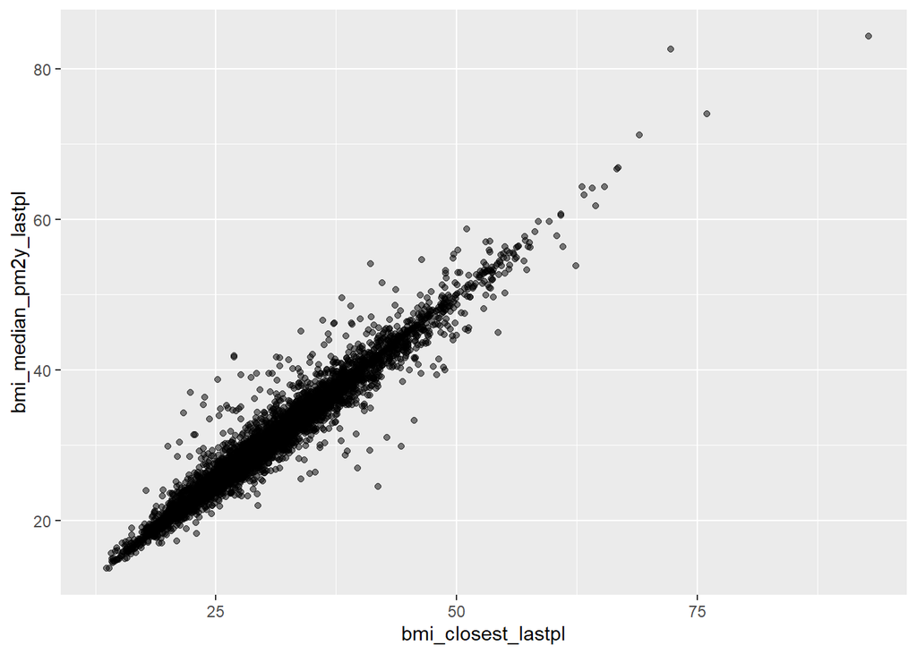

```r
ggplot(pool, aes(x = bmi_closest_lastpl, y = bmi_median_pm2y_lastpl)) +
        geom_point(alpha = 0.5)
```

### 3.1.4. BMI within (+/-)3 years of last plasma date

```r
## Generate variables on BMI records from within (+/-)3 years of last plasma date

pool <- bmi_vars_fnc(restriction = "abs(bmi_timegap_y) <= 3", varname_suffix = "_pm3y_lastpl")


## Check median BMI from within (+/-)3 years against BMI closest to last plasma date

pool[, .N, .(has_bmi_closest_lastpl, has_bmi_rec_pm3y_lastpl)]
```

```
##    has_bmi_closest_lastpl has_bmi_rec_pm3y_lastpl    N
## 1:                      1                       1 7996
## 2:                      0                       0  553
## 3:                      1                       0  217
```

```r
pool[, summary(bmi_closest_timegap_d_pm3y_lastpl)]
```

```
##      Min.   1st Qu.    Median      Mean   3rd Qu.      Max.      NA's
## -1085.000    -6.000     0.000     1.306     6.000  1094.000       770
```

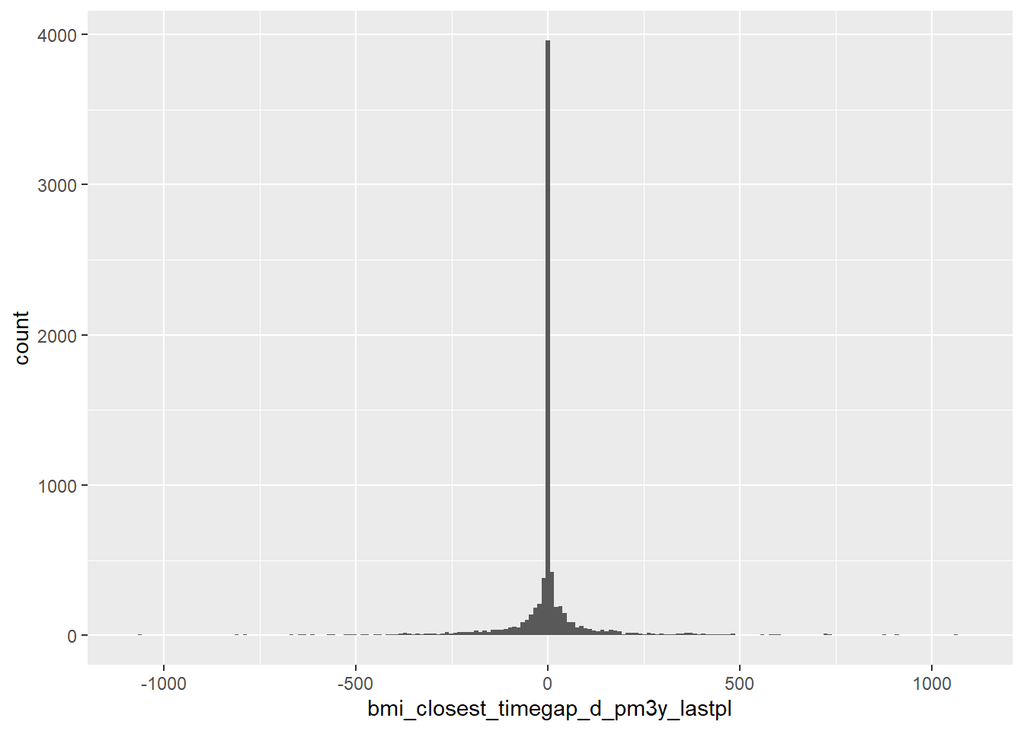

```r
ggplot(pool) + geom_histogram(aes(x = bmi_closest_timegap_d_pm3y_lastpl), bins = 200)
```

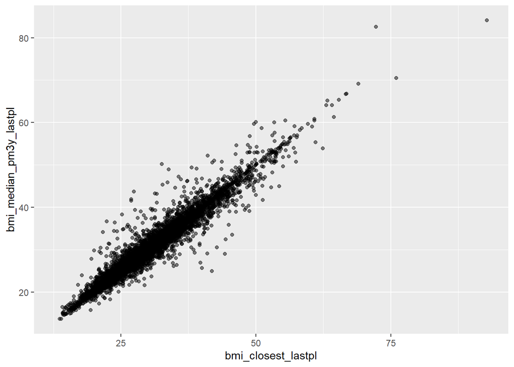

```r
ggplot(pool, aes(x = bmi_closest_lastpl, y = bmi_median_pm3y_lastpl)) +
        geom_point(alpha = 0.5)
```

## 3.2. Smoking ever

```r
phy[grepl("smok|tobac|cig", Concept_Name, ignore.case = T), .(Concept_Name, Code, Code_Type)][order(Code)] %>% unique()
```

```
##                                                  Concept_Name           Code
##  1:                                                    Smoker           3208
##  2:                                            Smoking status           4082
##  3:                                Second hand smoke exposure            527
##  4:                                            Smoking status        8895.23
##  5:                                           Chewing Tobacco        SH-CHEW
##  6:                                                    Cigars        SH-CIGR
##  7:                                                Cigarettes        SH-CIGS
##  8:                        Smokeless Tobacco Use-Current User SH-SMKLSTBCO-1
##  9:                         Smokeless Tobacco Use-Former User SH-SMKLSTBCO-2
## 10:                          Smokeless Tobacco Use-Never Used SH-SMKLSTBCO-3
## 11:                             Smokeless Tobacco Use-Unknown SH-SMKLSTBCO-4
## 12:              Smoking Tobacco Use-Current Every Day Smoker   SH-SMKTBCO-1
## 13:                  Smoking Tobacco Use-Light Tobacco Smoker  SH-SMKTBCO-10
## 14:               Smoking Tobacco Use-Current Some Day Smoker   SH-SMKTBCO-2
```

[output cut: 55 more lines]

```r
phy[grepl("Smoking status", Concept_Name), .N, .(Concept_Name, Result)] %>% datatable()
```

|  | Concept_Name | Result | N |
| --- | --- | --- | --- |
| 1 | Smoking status | Never Smoker | 25067 |
| 2 | Smoking status | Former smoker | 481 |
| 3 | Smoking status | Smoker, current status unknown | 426 |
| 4 | Smoking status | Former Smoker | 10548 |
| 5 | Smoking status | Current every day smoker | 2618 |
| 6 | Smoking status | Unknown, if ever smoked | 418 |
| 7 | Smoking status | quit in 1999 | 1 |
| 8 | Smoking status | Current some day smoker | 507 |
| 9 | Smoking status | Quit tobacco &gt;= 1 year ago | 266 |
| 10 | Smoking status | quit 10 months ago | 1 |

[output cut: 859 more lines]

```r
phy[grepl("Cig|Chewing Tobacco", Concept_Name), .N, .(Concept_Name, Code, Result)] # Not specific to any hospital
```

```
##       Concept_Name    Code Result     N
## 1:      Cigarettes SH-CIGS      Y 20107
## 2:          Cigars SH-CIGR      Y   762
## 3: Chewing Tobacco SH-CHEW      Y   245
```

```r
phy[grepl("TBCO-|QUIT-", Code), .N, .(Concept_Name, Code, Result)][order(Code)]
```

```
##                                                  Concept_Name           Code
##  1:                        Smokeless Tobacco Use-Current User SH-SMKLSTBCO-1
##  2:                         Smokeless Tobacco Use-Former User SH-SMKLSTBCO-2
##  3:                          Smokeless Tobacco Use-Never Used SH-SMKLSTBCO-3
##  4:                             Smokeless Tobacco Use-Unknown SH-SMKLSTBCO-4
##  5:              Smoking Tobacco Use-Current Every Day Smoker   SH-SMKTBCO-1
##  6:                  Smoking Tobacco Use-Light Tobacco Smoker  SH-SMKTBCO-10
##  7:               Smoking Tobacco Use-Current Some Day Smoker   SH-SMKTBCO-2
##  8:        Smoking Tobacco Use-Smoker, Current Status Unknown   SH-SMKTBCO-3
##  9:                         Smoking Tobacco Use-Former Smoker   SH-SMKTBCO-4
## 10:                          Smoking Tobacco Use-Never Smoker   SH-SMKTBCO-5
## 11:                        Smoking Tobacco Use-Never Assessed   SH-SMKTBCO-6
## 12: Smoking Tobacco Use-Passive Smoke Exposure - Never Smoker   SH-SMKTBCO-7
## 13:                Smoking Tobacco Use-Unknown if Ever Smoked   SH-SMKTBCO-8
## 14:                  Smoking Tobacco Use-Heavy Tobacco Smoker   SH-SMKTBCO-9
```

[output cut: 31 more lines]

```r
smk <- phy[Code %in% phy[grepl("TBCO-|QUIT-", Code) | grepl("Cig|Chewing Tobacco", Concept_Name), unique(Code)], ]
smk[, smk_ever := case_when(Code %in% c("SH-CIGS", "SH-CIGR", "SH-CHEW", "SH-SMKLSTBCO-1", "SH-SMKLSTBCO-2",
                                        "SH-SMKTBCO-1", "SH-SMKTBCO-2", "SH-SMKTBCO-4", "SH-SMKTBCO-9",
                                        "SH-SMKTBCO-10", "SH-TBCO-1", "SH-TBCO-4", "SMK2QUIT-1", "SMK2QUIT-2") ~ 1,
                            Code %in% c("SH-SMKLSTBCO-3", "SH-SMKTBCO-5", "SH-SMKTBCO-7", "SH-TBCO-2") ~ 0)]
smk_per_subj <- smk[!is.na(smk_ever), .(smk_ever_alltime = ifelse(sum(smk_ever) > 0, 1, 0)), EMPI]
pool <- merge(pool, smk_per_subj, by = "EMPI", all.x = T)
pool[, .N, smk_ever_alltime]
```

```
##    smk_ever_alltime    N
## 1:                1 3496
## 2:                0 4631
## 3:               NA  639
```

```r
## Remove phy object to free up memory

rm(phy); gc()
```

```
##             used  (Mb) gc trigger   (Mb)  max used   (Mb)
## Ncells   1675947  89.6    6332932  338.3   7916164  422.8
## Vcells 103728867 791.4  332185176 2534.4 519039337 3960.0
```

# 4. Lab test data

- ACTH
- Cortisol
- Eosinophil
- Total IgE

```r
lab <- fread(str_c(rpdr_file_header, "Lab", rpdr_file_ending), quote = "")
lab[, unique(EMPI)] %in% pool[, EMPI] %>% table()
```

```
## .
## FALSE  TRUE
##  8281  8302
```

```r
lab <- lab[EMPI %in% pool$EMPI, ] # Restrict to subjects in selection pool

lab[, Lab_Date := as.Date(substr(Seq_Date_Time, 1, 10), format = "%m/%d/%Y")]
lab[grepl(":", Seq_Date_Time), ':='(Lab_Hour = gsub("(.*) (.*):(.*)", "\\2", Seq_Date_Time),
                                    Lab_Minute = gsub("(.*) (.*):(.*)", "\\3", Seq_Date_Time))]
lab[, summary(Lab_Date)]
```

```
##         Min.      1st Qu.       Median         Mean      3rd Qu.         Max.
## "1988-09-22" "2009-08-11" "2014-03-17" "2012-10-11" "2017-07-11" "2020-07-01"
```

```r
lab <- merge(lab, pool[, .(EMPI, last_plasma_date)], by = "EMPI", all.x = T)
lab[, lab_timegap_d := as.numeric(Lab_Date - last_plasma_date)][, lab_timegap_y := lab_timegap_d/365.25]
lab[, summary(lab_timegap_y)]
```

```
##    Min. 1st Qu.  Median    Mean 3rd Qu.    Max.
## -29.944  -6.286  -1.432  -2.993   1.128   9.703
```

```r
lab_condensed <- lab %>% group_by(Group_Id, Loinc_Code, Test_Id, Test_Description, Specimen_Type) %>%
        summarise() %>% as.data.table()
```

## 4.1. ACTH

```r
lab_condensed[grepl("(?i)acth", Group_Id), ] %>% datatable()
```

|  | Group_Id | Loinc_Code | Test_Id | Test_Description | Specimen_Type |
| --- | --- | --- | --- | --- | --- |
| 1 | ACTH (Corticotropin) | 2141-0 | 1-205 | ACTH | BLOOD |
| 2 | ACTH (Corticotropin) | 2141-0 | 50.0250 | ACTH |  |
| 3 | ACTH (Corticotropin) | 2141-0 | 601.1100 | ACTH, PLASMA |  |
| 4 | ACTH (Corticotropin) | 2141-0 | 81.8610 | ADRENOCORTICOTROPIC HORMONE, P |  |
| 5 | ACTH (Corticotropin) | 2141-0 | 953.1870 | ADRENOCORTICOTROPIC HORMONE |  |
| 6 | ACTH (Corticotropin) | 2141-0 | ACTH | Adrenocorticotropic Hormone |  |
| 7 | ACTH (Corticotropin) | 2141-0 | ACTH | Adrenocorticotropic Hormone | BLOOD |
| 8 | ACTH (Corticotropin) | 2141-0 | ACTHOR | ACTH |  |
| 9 | ACTH (Corticotropin) | 2141-0 | ACTHT | ACTH |  |
| 10 | ACTH (Corticotropin) | 2141-0 | MACTH1 | ACTH |  |

[output cut: 9 more lines]

```r
lab_condensed[grepl("(?i)acth", Group_Id), ][, .N, .(Group_Id, Loinc_Code)]
```

```
##                       Group_Id Loinc_Code  N
## 1:        ACTH (Corticotropin)     2141-0 16
## 2:    Cortisol (1hr post ACTH)    26528-0  1
## 3: Cortisol (30 min post ACTH)    26530-6  2
```

```r
acth_code <- unique(lab_condensed[Group_Id == "ACTH (Corticotropin)", Loinc_Code])
acth_long <- lab[Loinc_Code == acth_code, ]

acth_long[, .N, Reference_Units] # Appear to be all pg/ml
```

```
##    Reference_Units   N
## 1:           pg/ml 347
## 2:           pg/mL 778
## 3:           PG/ML   3
## 4:                   4
```

```r
acth_long[, acth := as.numeric(Result)]
acth_long[is.na(acth), .N, Result] %>% datatable()
```

|  | Result | N |
| --- | --- | --- |
| 1 | &lt;5.0 | 52 |
| 2 | &lt;5 | 28 |
| 3 | CREDIT | 3 |
| 4 | REFUSED | 5 |
| 5 | &lt;1 | 5 |
| 6 | Credit | 1 |
| 7 | &lt;10 | 4 |
| 8 | &lt;2 | 3 |
| 9 | UNSATISFACTORY, SPECIMEN UNLABELED (REJECTED) | 1 |
| 10 | &lt; 2 | 3 |

[output cut: 8 more lines]

```r
acth_long[, summary(acth)] # Are values in 10-20k range plausible?
```

```
##    Min. 1st Qu.  Median    Mean 3rd Qu.    Max.    NA's
##     1.0    11.0    21.0   155.4    46.0 27900.0     121
```

### 4.1.1. ACTH closest to last plasma date

```r
acth_long <- acth_long[!is.na(acth), ]
acth_long[, acth_timegap_d_abs := abs(lab_timegap_d)]
setkey(acth_long, EMPI, acth_timegap_d_abs)
acth_closest <- acth_long[, head(.SD, 1), EMPI]
acth_closest[, .N, .(`acth_absolute_timegap<=7d` = acth_timegap_d_abs <= 7,
                     `acth_absolute_timegap<=1y` = abs(lab_timegap_y) <= 1)
             ][order(`acth_absolute_timegap<=7d`, `acth_absolute_timegap<=1y`)]
```

```
##    acth_absolute_timegap<=7d acth_absolute_timegap<=1y   N
## 1:                     FALSE                     FALSE 237
## 2:                     FALSE                      TRUE  92
## 3:                      TRUE                      TRUE  33
```

```r
setnames(acth_closest, c("acth", "Lab_Date", "Reference_Units"),
         str_c(c("acth", "acth_date", "acth_unit"), "_closest_lastpl"))
tmp_cols <- c("EMPI", str_c(c("acth", "acth_date", "acth_unit"), "_closest_lastpl"))
pool <- merge(pool, acth_closest[, ..tmp_cols], by = "EMPI", all.x = T)
pool[, has_acth_closest_lastpl := ifelse(!is.na(acth_closest_lastpl), 1, 0) %>% as.factor()]

pool[, .N, has_acth_closest_lastpl]
```

```
##    has_acth_closest_lastpl    N
## 1:                       0 8404
## 2:                       1  362
```

```r
pool[, summary(acth_closest_lastpl)]
```

```
##    Min. 1st Qu.  Median    Mean 3rd Qu.    Max.    NA's
##    1.00   10.00   16.00   28.23   24.00 2410.00    8404
```

```r
pool[, summary(as.numeric(acth_date_closest_lastpl - last_plasma_date))]
```

```
##     Min.  1st Qu.   Median     Mean  3rd Qu.     Max.     NA's
## -10187.0  -1254.8     -4.5   -656.0    441.5   3184.0     8404
```

### 4.1.2. ACTH within (+/-)1 year of last plasma date

```r
## Function to generate variables on ACTH under certain restriction

acth_vars_fnc <- function(restriction, varname_suffix) {
        acth_tmp <- eval(parse(text = str_c("acth_long[", restriction, ", ]")))
        acth_per_subj <- acth_tmp[, .(n_acth_rec = .N,
                                      acth_all_values = str_c(acth, collapse = ";"),
                                      acth_all_dates = str_c(Lab_Date, collapse = ";"),
                                      acth_median = median(acth),
                                      acth_min = min(acth),
                                      acth_max = max(acth),
                                      acth_mean = mean(acth)), EMPI]
        acth_per_subj <- eval(parse(text = str_c("merge(acth_per_subj, acth_closest[", restriction,
                                                 ", .(EMPI, lab_timegap_d)], by = 'EMPI', all.x = T)")))
        setnames(acth_per_subj, "lab_timegap_d", "acth_closest_timegap_d")
        setnames(acth_per_subj, c("EMPI", str_c(colnames(acth_per_subj)[-1], varname_suffix)))
        pool <- merge(pool, acth_per_subj, by = "EMPI", all.x = T)
        eval(parse(text = str_c("pool[, has_acth_rec", varname_suffix, " := ifelse(!is.na(n_acth_rec",
                                varname_suffix, "), 1, 0) %>% as.factor()]")))
        return(pool)
}


## Generate variables on acth records from within (+/-)1 year of last plasma date

pool <- acth_vars_fnc(restriction = "abs(lab_timegap_y) <= 1", varname_suffix = "_pm1y_lastpl")


## Check median acth from within (+/-)1 year against acth closest to last plasma date

pool[, .N, .(has_acth_closest_lastpl, has_acth_rec_pm1y_lastpl)]
```

```
##    has_acth_closest_lastpl has_acth_rec_pm1y_lastpl    N
## 1:                       0                        0 8404
## 2:                       1                        0  237
## 3:                       1                        1  125
```

```r
pool[, summary(acth_closest_timegap_d_pm1y_lastpl)]
```

```
##    Min. 1st Qu.  Median    Mean 3rd Qu.    Max.    NA's
##  -356.0   -68.0     0.0    13.7    90.0   349.0    8641
```

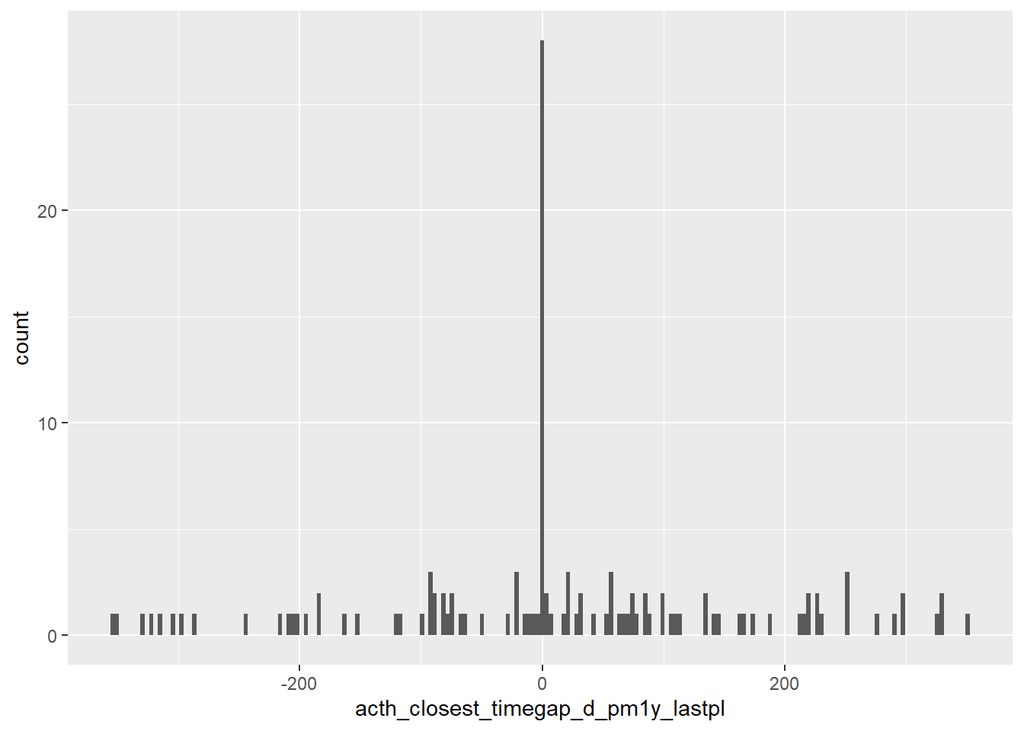

```r
ggplot(pool) + geom_histogram(aes(x = acth_closest_timegap_d_pm1y_lastpl), bins = 200)
```

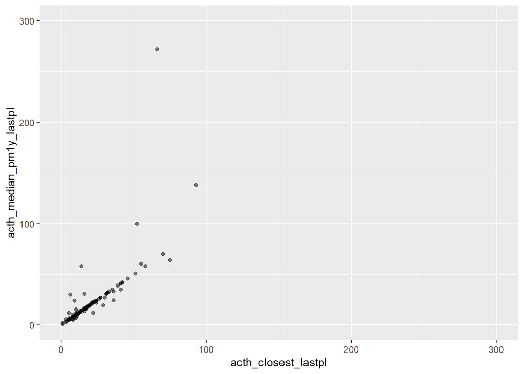

```r
# ggplot(pool, aes(x = acth_closest_lastpl, y = acth_median_pm1y_lastpl)) +
#         geom_point(alpha = 0.5)
ggplot(pool, aes(x = acth_closest_lastpl, y = acth_median_pm1y_lastpl)) +
        geom_point(alpha = 0.5) +
        xlim(0, 300) + ylim(0, 300)
```

### 4.1.3. ACTH within (+/-)2 years of last plasma date

```r
## Generate variables on acth records from within (+/-)2 years of last plasma date

pool <- acth_vars_fnc(restriction = "abs(lab_timegap_y) <= 2", varname_suffix = "_pm2y_lastpl")


## Check median acth from within (+/-)2 years against acth closest to last plasma date

pool[, .N, .(has_acth_closest_lastpl, has_acth_rec_pm2y_lastpl)]
```

```
##    has_acth_closest_lastpl has_acth_rec_pm2y_lastpl    N
## 1:                       0                        0 8404
## 2:                       1                        0  188
## 3:                       1                        1  174
```

```r
pool[, summary(acth_closest_timegap_d_pm2y_lastpl)]
```

```
##    Min. 1st Qu.  Median    Mean 3rd Qu.    Max.    NA's
## -709.00  -98.25    0.00   15.71  204.75  729.00    8592
```

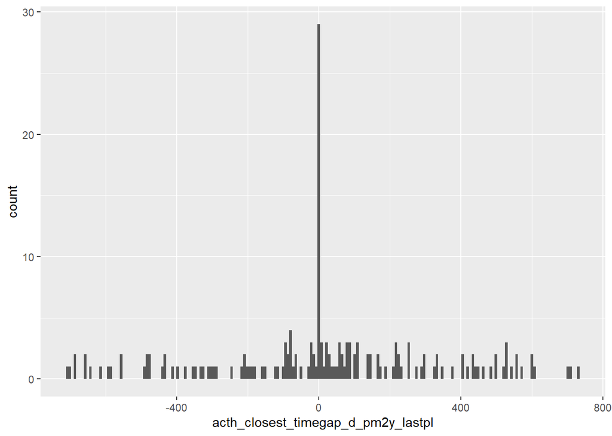

```r
ggplot(pool) + geom_histogram(aes(x = acth_closest_timegap_d_pm2y_lastpl), bins = 200)
```

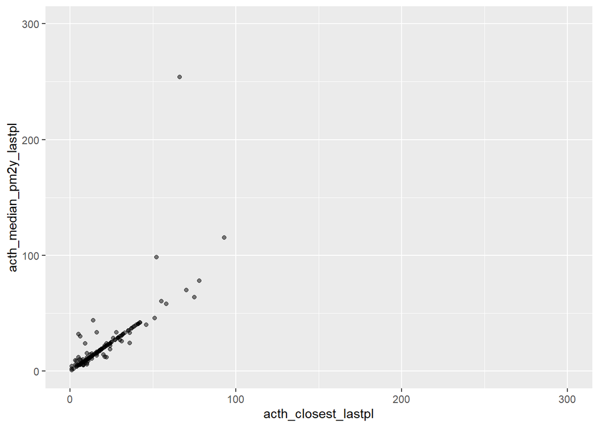

```r
ggplot(pool, aes(x = acth_closest_lastpl, y = acth_median_pm2y_lastpl)) +
        geom_point(alpha = 0.5) +
        xlim(0, 300) + ylim(0, 300)
```

### 4.1.4. ACTH within (+/-)3 years of last plasma date

```r
## Generate variables on acth records from within (+/-)3 years of last plasma date

pool <- acth_vars_fnc(restriction = "abs(lab_timegap_y) <= 3", varname_suffix = "_pm3y_lastpl")


## Check median acth from within (+/-)3 years against acth closest to last plasma date

pool[, .N, .(has_acth_closest_lastpl, has_acth_rec_pm3y_lastpl)]
```

```
##    has_acth_closest_lastpl has_acth_rec_pm3y_lastpl    N
## 1:                       0                        0 8404
## 2:                       1                        0  149
## 3:                       1                        1  213
```

```r
pool[, summary(acth_closest_timegap_d_pm3y_lastpl)]
```

```
##     Min.  1st Qu.   Median     Mean  3rd Qu.     Max.     NA's
## -1090.00  -195.00     0.00    28.73   298.00  1093.00     8553
```

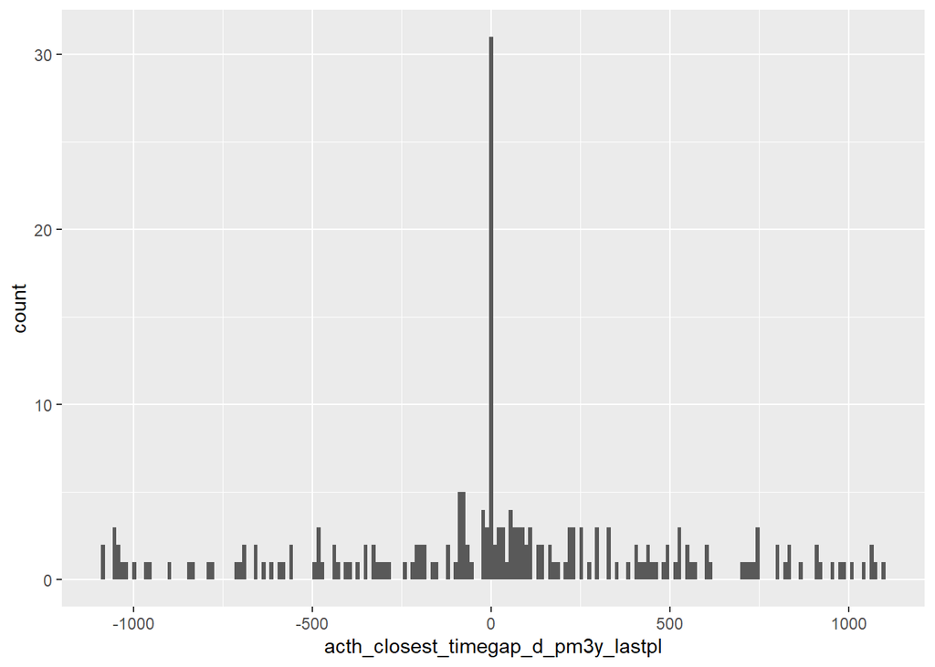

```r
ggplot(pool) + geom_histogram(aes(x = acth_closest_timegap_d_pm3y_lastpl), bins = 200)
```

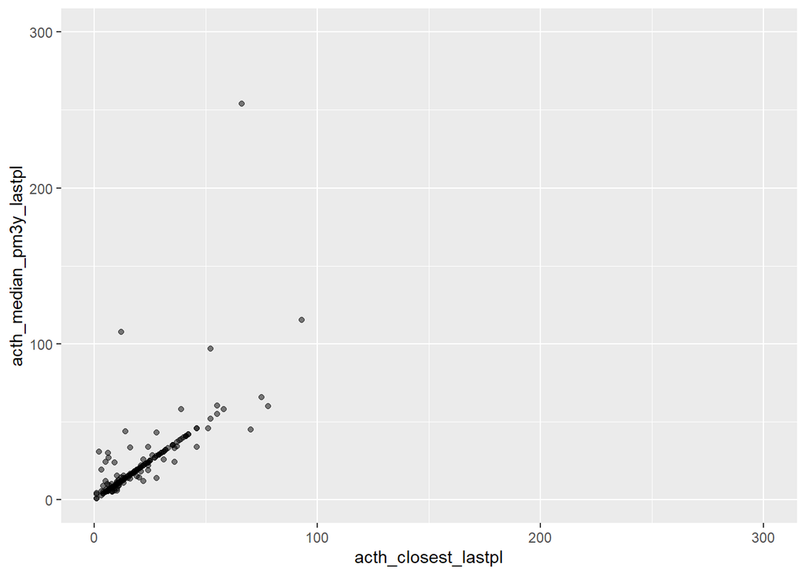

```r
ggplot(pool, aes(x = acth_closest_lastpl, y = acth_median_pm3y_lastpl)) +
        geom_point(alpha = 0.5) +
        xlim(0, 300) + ylim(0, 300)
```

## 4.2. Cortisol (not from urine)

```r
lab_condensed[grepl("(?i)cortisol", Group_Id), ] %>% datatable()
```

|  | Group_Id | Loinc_Code | Test_Id | Test_Description | Specimen_Type |
| --- | --- | --- | --- | --- | --- |
| 1 | Cortisol | 10332-5 | 326.2570 | CORTISOL, BASELINE |  |
| 2 | Cortisol | 10332-5 | 401.1400 | CORTISOL, BASELINE |  |
| 3 | Cortisol | 1403-5 | 326.2580 | CORTISOL,1 HOUR |  |
| 4 | Cortisol | 1403-5 | 401.1600 | CORTISOL, 1 HOUR |  |
| 5 | Cortisol | 1418-3 | 401.1500 | CORTISOL, 1/2 HOUR |  |
| 6 | Cortisol | 2143-6 | 1-212 | CORTISOL | BLOOD |
| 7 | Cortisol | 2143-6 | 326.2590 | CORTISOL |  |
| 8 | Cortisol | 2143-6 | 401.1300 | CORTISOL, SERUM |  |
| 9 | Cortisol | 2143-6 | 600.1100 | CORTISOL |  |
| 10 | Cortisol | 2143-6 | 600.1101 | CORTISOL (MGH) |  |

[output cut: 48 more lines]

```r
lab_condensed[grepl("(?i)cortisol", Group_Id), ][, .N, .(Group_Id, Loinc_Code)]
```

```
##                         Group_Id Loinc_Code  N
##  1:                     Cortisol    10332-5  2
##  2:                     Cortisol     1403-5  2
##  3:                     Cortisol     1418-3  1
##  4:                     Cortisol     2143-6 21
##  5:                     Cortisol    47608-5  1
##  6:                     Cortisol     9613-1  1
##  7:              Cortisol (12am)    58642-0  1
##  8:     Cortisol (1hr post ACTH)    26528-0  1
##  9:  Cortisol (30 min post ACTH)    26530-6  2
## 10:       Cortisol (AM specimen)    58674-3  1
## 11:       Cortisol (AM specimen)     9813-7  7
## 12: Cortisol, Free (timed urine)     2147-7 12
## 13:        Cortisol, PM specimen    58668-5  1
## 14:        Cortisol, PM specimen     9812-9  5
```

```r
cortisol_code <- unique(lab_condensed[Group_Id %in% c("Cortisol", "Cortisol (12am)", "Cortisol (AM specimen)",
                                                      "Cortisol, PM specimen", "Cortisol (1hr post ACTH)",
                                                      "Cortisol (30 min post ACTH)"), Loinc_Code])
# Not including urine cortisol

cortisol_long <- lab[Loinc_Code %in% cortisol_code, ]
cortisol_long[, .N, Reference_Units][order(-N)]
```

```
##     Reference_Units    N
##  1:           ug/dl 4016
##  2:           ug/dL 1243
##  3:           UG/DL  157
##  4:          mcg/dL   20
##  5:           ug/ml    9
##  6:           ng/dL    6
##  7:          mcg/mL    4
##  8:           UG/ML    4
##  9:           ug/mL    3
## 10:    not reported    3
## 11:          MCG/DL    2
## 12:                    1
```

```r
cortisol_long[, cortisol := case_when(Reference_Units %in% c("ug/dl", "ug/dL", "UG/DL", "mcg/dL", "MCG/DL") ~ as.numeric(Result),
                                      Reference_Units %in% c("ug/ml", "UG/ML", "ug/mL", "mcg/mL") ~ as.numeric(Result)*100,
                                      Reference_Units %in% c("ng/dL") ~ as.numeric(Result)*0.001)
              ][, cortisol_unit := "ug/dl"] # Unify to ug/dl
cortisol_long[is.na(cortisol), .N, Result] %>% datatable()
```

|  | Result | N |
| --- | --- | --- |
| 1 | PEND | 2 |
| 2 | &lt;1.0 | 48 |
| 3 | UNSATISFACTORY, CORRECT SPECIMEN TYPE NOT RECEIVED | 1 |
| 4 | &lt;0.5 | 42 |
| 5 | UNSATISFACTORY, NO SPECIMEN RECEIVED NOTIFIED JEFF AT 1649 | 1 |
| 6 | UNSATISFACTORY, NO SPECIMEN RECEIVED | 7 |
| 7 | CREDITED: LOGIN ERROR | 1 |
| 8 | CREDIT | 1 |
| 9 | REFUSED | 6 |
| 10 | NSQ | 1 |

[output cut: 16 more lines]

```r
cortisol_long[, summary(cortisol)] # Are values in 1-2k range plausible?
```

```
##     Min.  1st Qu.   Median     Mean  3rd Qu.     Max.     NA's
##    0.026    5.800   10.700   17.349   17.900 2900.000      147
```

```r
## Separate regular cortisol from ACTH stim test cortisol

cort_reg_long <- cortisol_long[!grepl("(?i)acth", Group_Id) &
                                 !grepl("(?i)acth stim|hour", Test_Description) &
                                   !grepl("(?i)min|hour|minutes|acth|cort stim|cosyntropin", Result_Text), ]
# Exclude ACTH stim cortisol according to indications in Group_Id & Test_Description & Result_Text

cort_stim_long <- cortisol_long[grepl("(?i)acth", Group_Id) |
                                  grepl("(?i)acth stim|hour", Test_Description) |
                                    grepl("(?i)min|hour|minutes|acth|cort stim|cosyntropin", Result_Text), ]
# Only a total of 160 ACTH stim cortisol records
```

### 4.2.1. Cortisol closest to last plasma date

```r
cort_reg_long <- cort_reg_long[!is.na(cortisol), ]
cort_reg_long[, cortisol_timegap_d_abs := abs(lab_timegap_d)]
setkey(cort_reg_long, EMPI, cortisol_timegap_d_abs)
cortisol_closest <- cort_reg_long[, head(.SD, 1), EMPI]
cortisol_closest[, .N, .(`cortisol_absolute_timegap<=7d` = cortisol_timegap_d_abs <= 7,
                         `cortisol_absolute_timegap<=1y` = abs(lab_timegap_y) <= 1)
                 ][order(`cortisol_absolute_timegap<=7d`, `cortisol_absolute_timegap<=1y`)]
```

```
##    cortisol_absolute_timegap<=7d cortisol_absolute_timegap<=1y   N
## 1:                         FALSE                         FALSE 993
## 2:                         FALSE                          TRUE 351
## 3:                          TRUE                          TRUE 111
```

```r
setnames(cortisol_closest, c("cortisol", "Lab_Date", "cortisol_unit"),
         str_c(c("cortisol", "cortisol_date", "cortisol_unit"), "_closest_lastpl"))
tmp_cols <- c("EMPI", str_c(c("cortisol", "cortisol_date", "cortisol_unit"), "_closest_lastpl"))
pool <- merge(pool, cortisol_closest[, ..tmp_cols], by = "EMPI", all.x = T)
pool[, has_cortisol_closest_lastpl := ifelse(!is.na(cortisol_closest_lastpl), 1, 0) %>% as.factor()]

pool[, .N, has_cortisol_closest_lastpl]
```

```
##    has_cortisol_closest_lastpl    N
## 1:                           0 7311
## 2:                           1 1455
```

```r
pool[, summary(cortisol_closest_lastpl)]
```

```
##     Min.  1st Qu.   Median     Mean  3rd Qu.     Max.     NA's
##    0.154    5.650    9.800   15.713   15.800 2180.000     7311
```

```r
pool[, summary(as.numeric(cortisol_date_closest_lastpl - last_plasma_date))]
```

```
##     Min.  1st Qu.   Median     Mean  3rd Qu.     Max.     NA's
## -10406.0  -2129.0   -181.0  -1029.2    228.5   2905.0     7311
```

### 4.2.2. Cortisol within (+/-)1 year of last plasma date

```r
## Function to generate variables on Cortisol under certain restriction

cortisol_vars_fnc <- function(restriction, varname_suffix) {
        cortisol_tmp <- eval(parse(text = str_c("cort_reg_long[", restriction, ", ]")))
        cortisol_per_subj <- cortisol_tmp[, .(n_cortisol_rec = .N,
                                              cortisol_all_values = str_c(cortisol, collapse = ";"),
                                              cortisol_all_dates = str_c(Lab_Date, collapse = ";"),
                                              cortisol_median = median(cortisol),
                                              cortisol_min = min(cortisol),
                                              cortisol_max = max(cortisol),
                                              cortisol_mean = mean(cortisol)), EMPI]
        cortisol_per_subj <- eval(parse(text = str_c("merge(cortisol_per_subj, cortisol_closest[", restriction,
                                                     ", .(EMPI, lab_timegap_d)], by = 'EMPI', all.x = T)")))
        setnames(cortisol_per_subj, "lab_timegap_d", "cortisol_closest_timegap_d")
        setnames(cortisol_per_subj, c("EMPI", str_c(colnames(cortisol_per_subj)[-1], varname_suffix)))
        pool <- merge(pool, cortisol_per_subj, by = "EMPI", all.x = T)
        eval(parse(text = str_c("pool[, has_cortisol_rec", varname_suffix, " := ifelse(!is.na(n_cortisol_rec",
                                varname_suffix, "), 1, 0) %>% as.factor()]")))
        return(pool)
}


## Generate variables on cortisol records from within (+/-)1 year of last plasma date

pool <- cortisol_vars_fnc(restriction = "abs(lab_timegap_y) <= 1", varname_suffix = "_pm1y_lastpl")


## Check median cortisol from within (+/-)1 year against cortisol closest to last plasma date

pool[, .N, .(has_cortisol_closest_lastpl, has_cortisol_rec_pm1y_lastpl)]
```

```
##    has_cortisol_closest_lastpl has_cortisol_rec_pm1y_lastpl    N
## 1:                           0                            0 7311
## 2:                           1                            0  993
## 3:                           1                            1  462
```

```r
pool[, summary(cortisol_closest_timegap_d_pm1y_lastpl)]
```

```
##    Min. 1st Qu.  Median    Mean 3rd Qu.    Max.    NA's
## -351.00  -50.00    0.00   20.96  105.00  364.00    8304
```

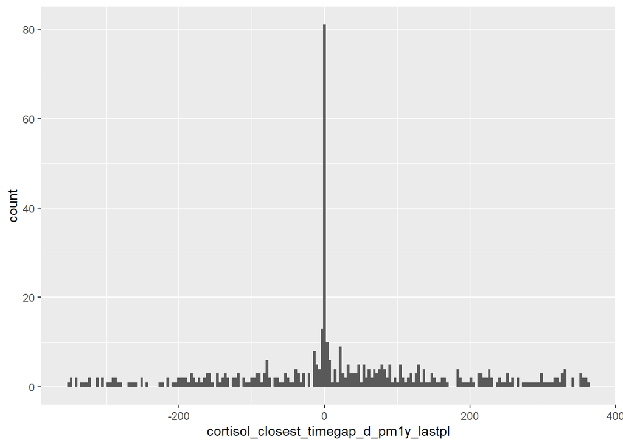

```r
ggplot(pool) + geom_histogram(aes(x = cortisol_closest_timegap_d_pm1y_lastpl), bins = 200)
```

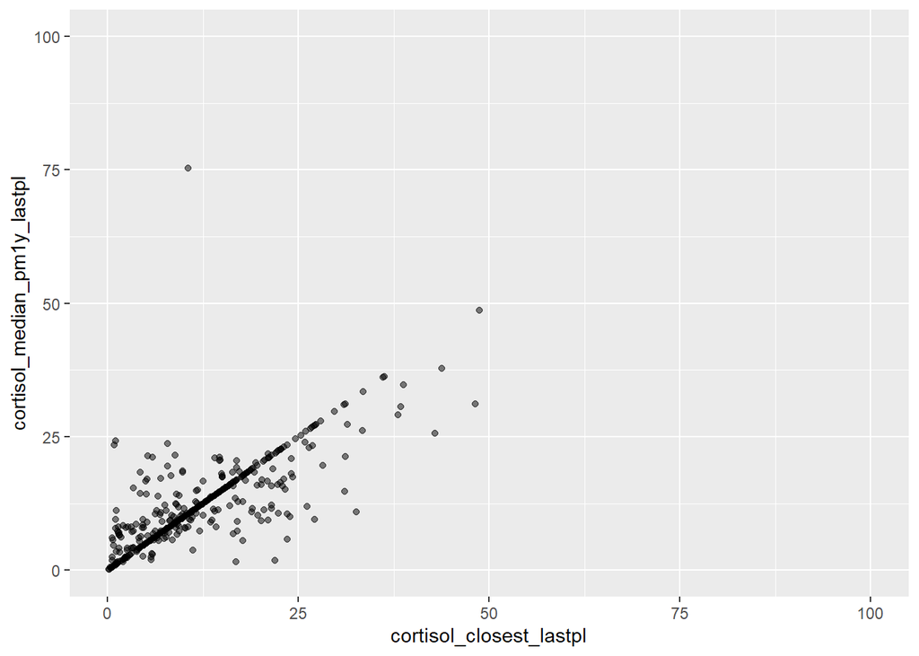

```r
# ggplot(pool, aes(x = cortisol_closest_lastpl, y = cortisol_median_pm1y_lastpl)) +
#         geom_point(alpha = 0.5) # The 810 value is likely unit entry error
ggplot(pool, aes(x = cortisol_closest_lastpl, y = cortisol_median_pm1y_lastpl)) +
        geom_point(alpha = 0.5) +
        xlim(0, 100) + ylim(0, 100)
```

### 4.2.3. Cortisol within (+/-)2 years of last plasma date

```r
## Generate variables on cortisol records from within (+/-)2 years of last plasma date

pool <- cortisol_vars_fnc(restriction = "abs(lab_timegap_y) <= 2", varname_suffix = "_pm2y_lastpl")


## Check median cortisol from within (+/-)2 years against cortisol closest to last plasma date

pool[, .N, .(has_cortisol_closest_lastpl, has_cortisol_rec_pm2y_lastpl)]
```

```
##    has_cortisol_closest_lastpl has_cortisol_rec_pm2y_lastpl    N
## 1:                           0                            0 7311
## 2:                           1                            0  792
## 3:                           1                            1  663
```

```r
pool[, summary(cortisol_closest_timegap_d_pm2y_lastpl)]
```

```
##    Min. 1st Qu.  Median    Mean 3rd Qu.    Max.    NA's
## -730.00 -121.50    1.00   31.18  224.50  726.00    8103
```

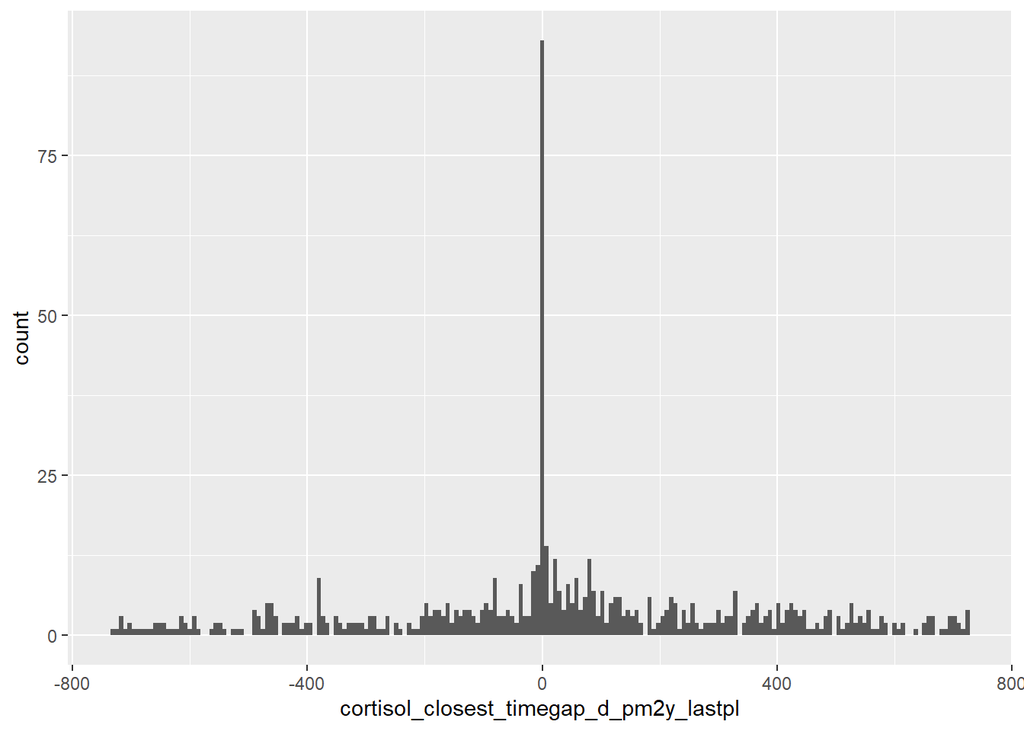

```r
ggplot(pool) + geom_histogram(aes(x = cortisol_closest_timegap_d_pm2y_lastpl), bins = 200)
```

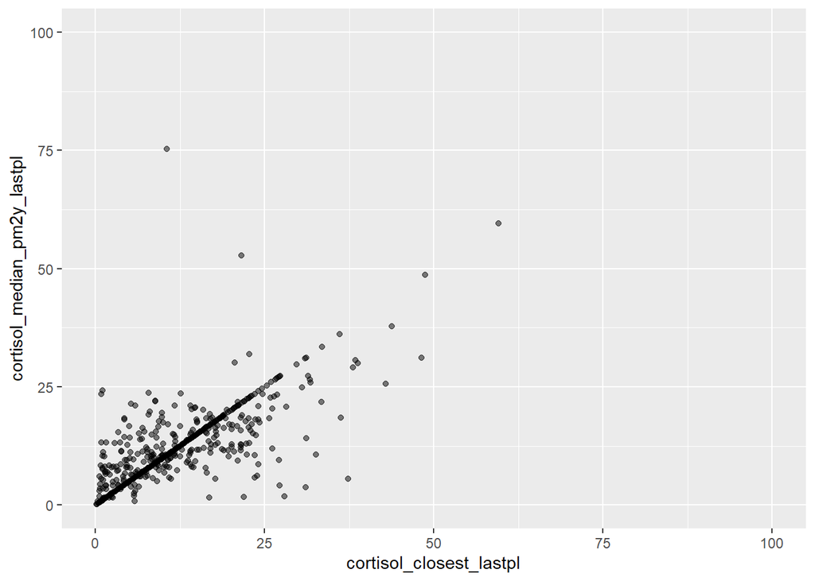

```r
ggplot(pool, aes(x = cortisol_closest_lastpl, y = cortisol_median_pm2y_lastpl)) +
        geom_point(alpha = 0.5) +
        xlim(0, 100) + ylim(0, 100)
```

### 4.2.4. Cortisol within (+/-)3 years of last plasma date

```r
## Generate variables on cortisol records from within (+/-)3 years of last plasma date

pool <- cortisol_vars_fnc(restriction = "abs(lab_timegap_y) <= 3", varname_suffix = "_pm3y_lastpl")


## Check median cortisol from within (+/-)3 years against cortisol closest to last plasma date

pool[, .N, .(has_cortisol_closest_lastpl, has_cortisol_rec_pm3y_lastpl)]
```

```
##    has_cortisol_closest_lastpl has_cortisol_rec_pm3y_lastpl    N
## 1:                           0                            0 7311
## 2:                           1                            0  656
## 3:                           1                            1  799
```

```r
pool[, summary(cortisol_closest_timegap_d_pm3y_lastpl)]
```

```
##      Min.   1st Qu.    Median      Mean   3rd Qu.      Max.      NA's
## -1090.000  -211.500     0.000     3.954   294.000  1093.000      7967
```

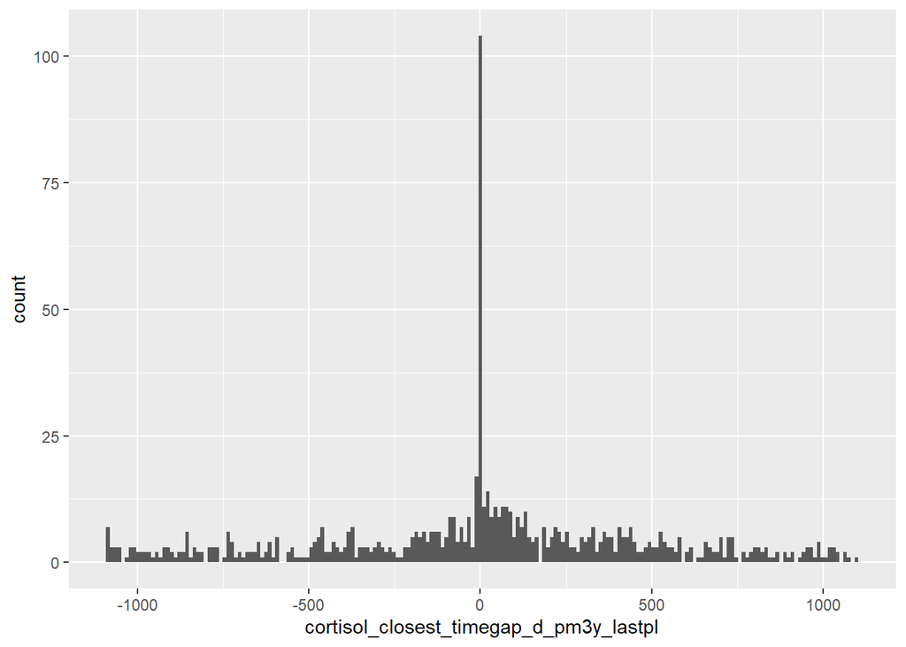

```r
ggplot(pool) + geom_histogram(aes(x = cortisol_closest_timegap_d_pm3y_lastpl), bins = 200)
```

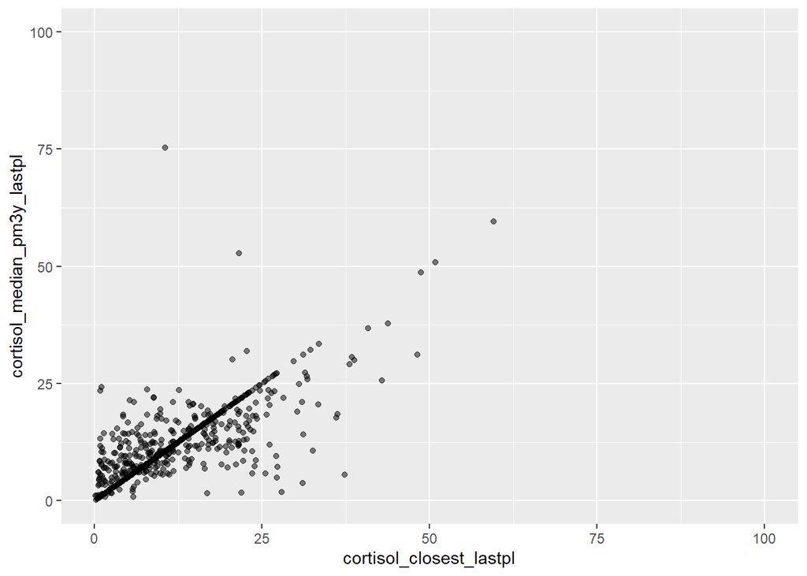

```r
ggplot(pool, aes(x = cortisol_closest_lastpl, y = cortisol_median_pm3y_lastpl)) +
        geom_point(alpha = 0.5) +
        xlim(0, 100) + ylim(0, 100)
```

## 4.3. Eosinophil count

```r
lab_condensed[grepl("(?i)eos", Group_Id), ] %>% datatable()
```

|  | Group_Id | Loinc_Code | Test_Id | Test_Description | Specimen_Type |
| --- | --- | --- | --- | --- | --- |
| 1 | Eos# | 26449-9 | AEOS | Absolute Eos |  |
| 2 | Eos# | 26449-9 | AEOS | Absolute EOS |  |
| 3 | Eos# | 26449-9 | AEOS | ABSOLUTE EOS |  |
| 4 | Eos# | 26449-9 | EOA | ABS EOS |  |
| 5 | Eos# | 26449-9 | EOAO | ABS EOS |  |
| 6 | Eos# | 26449-9 | SQ-AEO1 | Absolute Eos | CHC SP |
| 7 | Eos# | 26449-9 | SQ-AEO1 | Absolute Eos | CHC SPECIMEN |
| 8 | Eos# | 26449-9 | SQ-AEO3 | Absolute Eos | RHC SP |
| 9 | Eos# | 26449-9 | SQ-AEO3 | Absolute Eos | RHC SPECIMEN |
| 10 | Eos# | 26449-9 | SQ-AEO4 | Absolute Eos | MGPOL |

[output cut: 51 more lines]

```r
lab_condensed[grepl("(?i)eos", Group_Id), ][, .N, .(Group_Id, Loinc_Code)]
```

```
##         Group_Id Loinc_Code  N
## 1:          Eos#    26449-9 38
## 2:   Eos# (auto)      711-2 18
## 3: Eos# (manual)      712-0  5
```

```r
eos_code <- unique(lab_condensed[grepl("(?i)eos", Group_Id), Loinc_Code])

eos_long <- lab[Loinc_Code %in% eos_code, ]
eos_long[, .N, Reference_Units][order(-N)]
```

```
##     Reference_Units      N
##  1:            K/uL 113935
##  2:          th/cmm  30979
##  3:          th/mm3  13836
##  4:                  12493
##  5:            K/UL   4602
##  6:           K3/UL   1492
##  7:           K/MM3    516
##  8:           /cumm     75
##  9:           /CUMM     29
## 10:          /(MM3)     19
## 11:              UL     10
## 12:             /uL      8
```

```r
eos_long[, eos := case_when(Reference_Units %in% c("K/uL", "th/cmm", "th/mm3", "K/UL", "K/MM3", "") ~ as.numeric(Result),
                            Reference_Units %in% c("/cumm", "/(MM3)", "/CUMM", "UL", "/uL") ~ as.numeric(Result)*0.001)
         ][, eos_unit := "K/uL"] # Unify to K/uL
eos_long[is.na(eos), .N, Result] %>% datatable()
```

|  | Result | N |
| --- | --- | --- |
| 1 | SEE MANUAL DIFF RESULTS | 836 |
| 2 | 343/CMM | 1 |
| 3 | UNSATISFACTORY, SPECIMEN CLOTTED | 15 |
| 4 | UNLABELED SPECIMEN | 7 |
| 5 | UNSATISFACTORY, SPECIMEN MISLABELED (REJECTED) | 8 |
| 6 | NOT DONE | 31 |
| 7 | REQUEST CREDITED | 34 |
| 8 | 0.07 | 59 |
| 9 | 0.04 | 38 |
| 10 | 0.05 | 36 |

[output cut: 145 more lines]

```r
eos_long[, summary(eos)]
```

```
##     Min.  1st Qu.   Median     Mean  3rd Qu.     Max.     NA's
##    0.000    0.070    0.140    0.367    0.240 4000.000     2806
```

### 4.3.1. Eosinophil closest to last plasma date

```r
eos_long <- eos_long[!is.na(eos), ]
eos_long[, eos_timegap_d_abs := abs(lab_timegap_d)]
setkey(eos_long, EMPI, eos_timegap_d_abs)
eos_closest <- eos_long[, head(.SD, 1), EMPI]
eos_closest[, .N, .(`eos_absolute_timegap<=7d` = eos_timegap_d_abs <= 7,
                    `eos_absolute_timegap<=1y` = abs(lab_timegap_y) <= 1)
            ][order(`eos_absolute_timegap<=7d`, `eos_absolute_timegap<=1y`)]
```

```
##    eos_absolute_timegap<=7d eos_absolute_timegap<=1y    N
## 1:                    FALSE                    FALSE 2134
## 2:                    FALSE                     TRUE 3475
## 3:                     TRUE                     TRUE 2420
```

```r
setnames(eos_closest, c("eos", "Lab_Date", "eos_unit"),
         str_c(c("eos", "eos_date", "eos_unit"), "_closest_lastpl"))
tmp_cols <- c("EMPI", str_c(c("eos", "eos_date", "eos_unit"), "_closest_lastpl"))
pool <- merge(pool, eos_closest[, ..tmp_cols], by = "EMPI", all.x = T)
pool[, has_eos_closest_lastpl := ifelse(!is.na(eos_closest_lastpl), 1, 0) %>% as.factor()]

pool[, .N, has_eos_closest_lastpl]
```

```
##    has_eos_closest_lastpl    N
## 1:                      1 8029
## 2:                      0  737
```

```r
pool[, summary(eos_closest_lastpl)]
```

```
##     Min.  1st Qu.   Median     Mean  3rd Qu.     Max.     NA's
##   0.0000   0.0800   0.1500   0.2842   0.2500 258.0000      737
```

```r
pool[, summary(as.numeric(eos_date_closest_lastpl - last_plasma_date))]
```

```
##    Min. 1st Qu.  Median    Mean 3rd Qu.    Max.    NA's
## -9629.0  -147.0     0.0  -258.7    23.0  2479.0     737
```

### 4.3.2. Eosinophil within (+/-)1 year of last plasma date

```r
## Function to generate variables on Cortisol under certain restriction

eos_vars_fnc <- function(restriction, varname_suffix) {
        eos_tmp <- eval(parse(text = str_c("eos_long[", restriction, ", ]")))
        eos_per_subj <- eos_tmp[, .(n_eos_rec = .N,
                                    eos_all_values = str_c(eos, collapse = ";"),
                                    eos_all_dates = str_c(Lab_Date, collapse = ";"),
                                    eos_median = median(eos),
                                    eos_min = min(eos),
                                    eos_max = max(eos),
                                    eos_mean = mean(eos)), EMPI]
        eos_per_subj <- eval(parse(text = str_c("merge(eos_per_subj, eos_closest[", restriction,
                                                ", .(EMPI, lab_timegap_d)], by = 'EMPI', all.x = T)")))
        setnames(eos_per_subj, "lab_timegap_d", "eos_closest_timegap_d")
        setnames(eos_per_subj, c("EMPI", str_c(colnames(eos_per_subj)[-1], varname_suffix)))
        pool <- merge(pool, eos_per_subj, by = "EMPI", all.x = T)
        eval(parse(text = str_c("pool[, has_eos_rec", varname_suffix, " := ifelse(!is.na(n_eos_rec",
                                varname_suffix, "), 1, 0) %>% as.factor()]")))
        return(pool)
}


## Generate variables on eos records from within (+/-)1 year of last plasma date

pool <- eos_vars_fnc(restriction = "abs(lab_timegap_y) <= 1", varname_suffix = "_pm1y_lastpl")


## Check median eos from within (+/-)1 year against eos closest to last plasma date

pool[, .N, .(has_eos_closest_lastpl, has_eos_rec_pm1y_lastpl)]
```

```
##    has_eos_closest_lastpl has_eos_rec_pm1y_lastpl    N
## 1:                      1                       1 5895
## 2:                      1                       0 2134
## 3:                      0                       0  737
```

```r
pool[, summary(eos_closest_timegap_d_pm1y_lastpl)]
```

```
##     Min.  1st Qu.   Median     Mean  3rd Qu.     Max.     NA's
## -365.000  -29.000    0.000   -4.426   12.000  365.000     2871
```

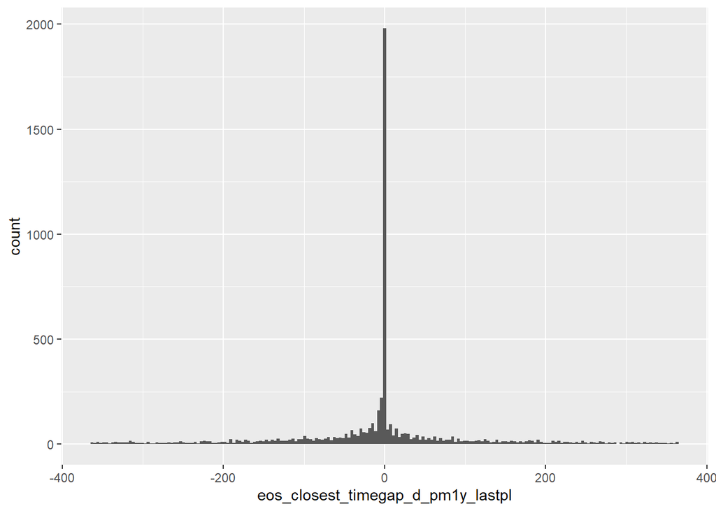

```r
ggplot(pool) + geom_histogram(aes(x = eos_closest_timegap_d_pm1y_lastpl), bins = 200)
```

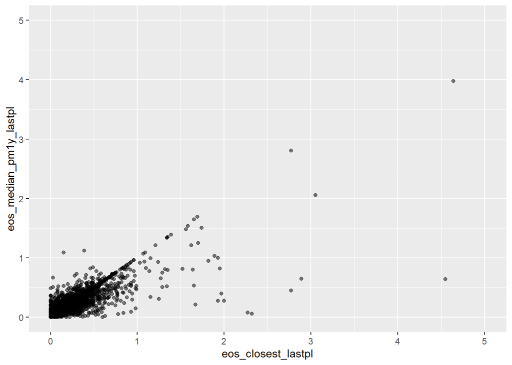

```r
ggplot(pool, aes(x = eos_closest_lastpl, y = eos_median_pm1y_lastpl)) +
        geom_point(alpha = 0.5) +
        xlim(0, 5) + ylim(0, 5)
```

### 4.3.3. Eosinophil within (+/-)2 years of last plasma date

```r
## Generate variables on eos records from within (+/-)2 years of last plasma date

pool <- eos_vars_fnc(restriction = "abs(lab_timegap_y) <= 2", varname_suffix = "_pm2y_lastpl")


## Check median eos from within (+/-)2 years against eos closest to last plasma date

pool[, .N, .(has_eos_closest_lastpl, has_eos_rec_pm2y_lastpl)]
```

```
##    has_eos_closest_lastpl has_eos_rec_pm2y_lastpl    N
## 1:                      1                       1 6714
## 2:                      1                       0 1315
## 3:                      0                       0  737
```

```r
pool[, summary(eos_closest_timegap_d_pm2y_lastpl)]
```

```
##     Min.  1st Qu.   Median     Mean  3rd Qu.     Max.     NA's
## -728.000  -47.000    0.000   -8.177   24.000  730.000     2052
```

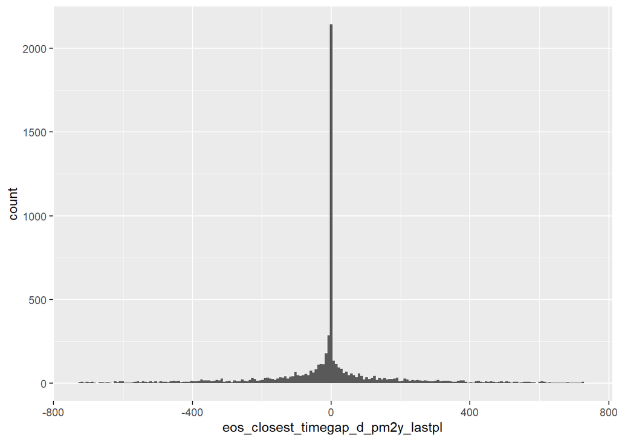

```r
ggplot(pool) + geom_histogram(aes(x = eos_closest_timegap_d_pm2y_lastpl), bins = 200)
```

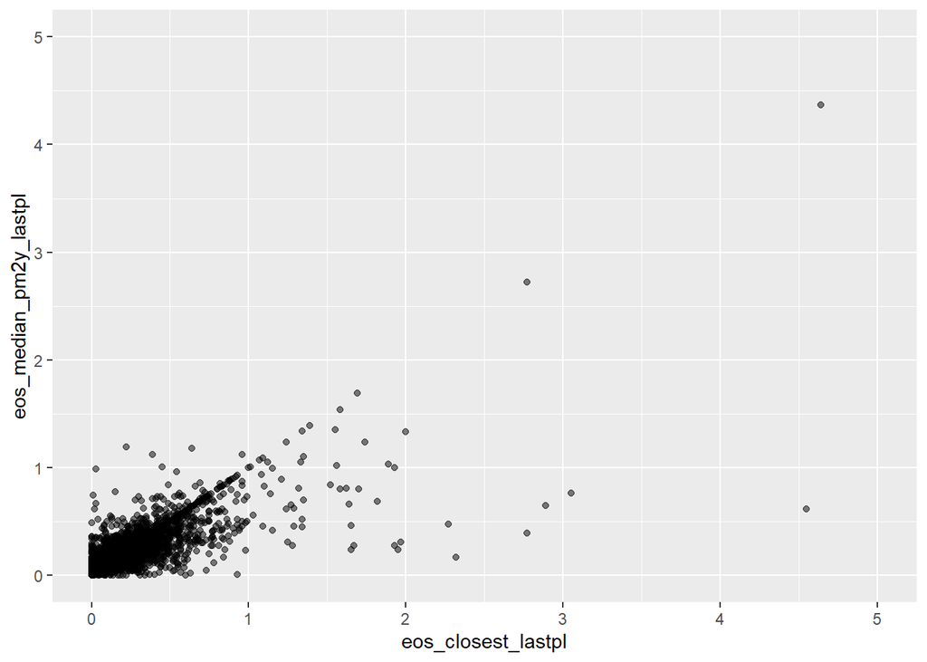

```r
ggplot(pool, aes(x = eos_closest_lastpl, y = eos_median_pm2y_lastpl)) +
        geom_point(alpha = 0.5) +
        xlim(0, 5) + ylim(0, 5)
```

### 4.3.4. Eosinophil within (+/-)3 years of last plasma date

```r
## Generate variables on eos records from within (+/-)3 years of last plasma date

pool <- eos_vars_fnc(restriction = "abs(lab_timegap_y) <= 3", varname_suffix = "_pm3y_lastpl")


## Check median eos from within (+/-)3 years against eos closest to last plasma date

pool[, .N, .(has_eos_closest_lastpl, has_eos_rec_pm3y_lastpl)]
```

```
##    has_eos_closest_lastpl has_eos_rec_pm3y_lastpl    N
## 1:                      1                       1 7123
## 2:                      1                       0  906
## 3:                      0                       0  737
```

```r
pool[, summary(eos_closest_timegap_d_pm3y_lastpl)]
```

```
##     Min.  1st Qu.   Median     Mean  3rd Qu.     Max.     NA's
## -1093.00   -62.00     0.00   -17.14    29.00  1083.00     1643
```

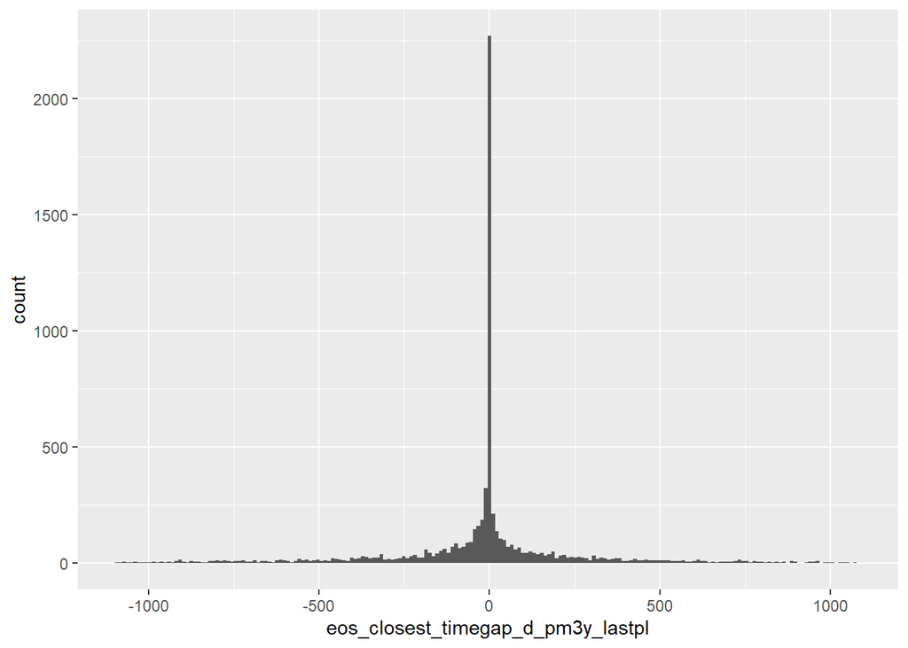

```r
ggplot(pool) + geom_histogram(aes(x = eos_closest_timegap_d_pm3y_lastpl), bins = 200)
```

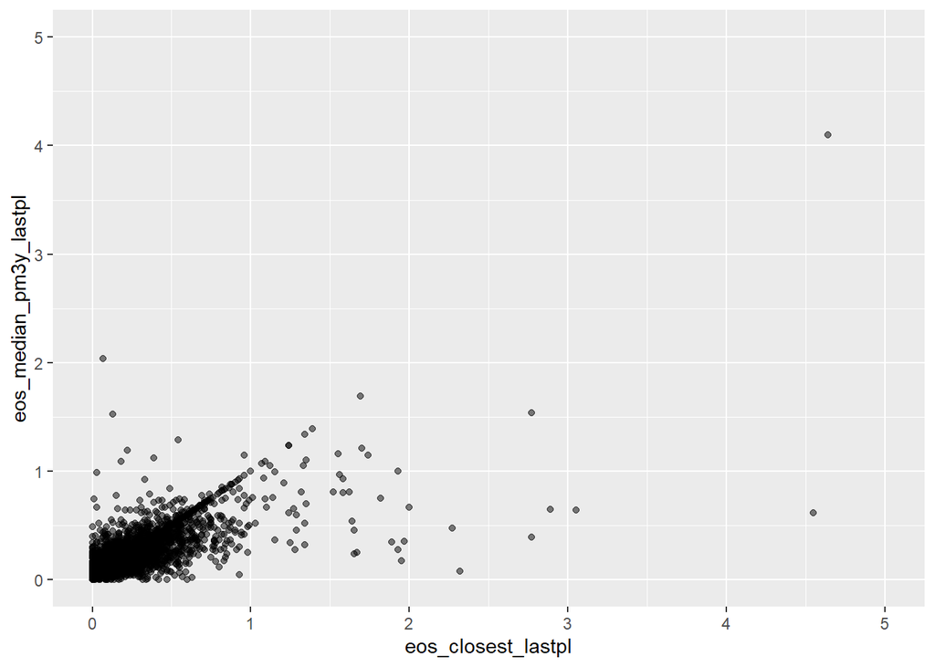

```r
ggplot(pool, aes(x = eos_closest_lastpl, y = eos_median_pm3y_lastpl)) +
        geom_point(alpha = 0.5) +
        xlim(0, 5) + ylim(0, 5)
```

## 4.4. Total IgE

```r
lab_condensed[grepl("(?i)ige", Group_Id), ] %>% datatable()
```

|  | Group_Id | Loinc_Code | Test_Id | Test_Description | Specimen_Type |
| --- | --- | --- | --- | --- | --- |
| 1 | IgE | 19113-0 | 1-258 | IGE | BLOOD |
| 2 | IgE | 19113-0 | 2314151 | IMMUNOGLOBULIN E |  |
| 3 | IgE | 19113-0 | 30503 | IgE |  |
| 4 | IgE | 19113-0 | 326.3650 | IMMUNOGLOBULIN E |  |
| 5 | IgE | 19113-0 | 402.0900 | IMMUNOGLOBULIN E SERUM |  |
| 6 | IgE | 19113-0 | 402.0902 | IMMUNOGLOBULIN E SERUM |  |
| 7 | IgE | 19113-0 | 451.0900 | TOTAL IMMUNOGLOBULIN E |  |
| 8 | IgE | 19113-0 | 50.1185 | IMMUNO IGE |  |
| 9 | IgE | 19113-0 | 81.7510 | IMMUNOGLOBULIN E (IGE), S |  |
| 10 | IgE | 19113-0 | IEM | IMMUNOGLOBULIN E |  |

[output cut: 27 more lines]

```r
lab_condensed[grepl("(?i)ige", Group_Id), ][, .N, .(Group_Id, Loinc_Code)]
```

```
##    Group_Id Loinc_Code  N
## 1:      IgE    19113-0 37
```

```r
ige_code <- unique(lab_condensed[grepl("(?i)ige", Group_Id), Loinc_Code])

ige_long <- lab[Loinc_Code %in% ige_code, ]
ige_long[, .N, Reference_Units][order(-N)]
```

```
##    Reference_Units    N
## 1:           IU/ml 2683
## 2:           IU/mL 1044
## 3:            kU/L  343
## 4:           IU/ML  136
## 5:           mg/dl   19
## 6:           ng/ml    2
## 7:            U/ML    1
## 8:                    1
```

```r
ige_long[, ige := case_when(Reference_Units %in% c("IU/ml", "IU/mL", "kU/L", "IU/ML", "U/ML", "") ~ as.numeric(Result),
                            Reference_Units %in% c("ng/ml") ~ as.numeric(Result)/2.4) # Ref: PMC3206235
         ][, ige_unit := "kU/L"] # Unify to kU/L
ige_long[is.na(ige), .N, Result] %>% datatable()
```

|  | Result | N |
| --- | --- | --- |
| 1 | &gt;5000 | 4 |
| 2 | &lt;15 | 10 |
| 3 | &lt;7.5 | 107 |
| 4 | &lt;10 | 27 |
| 5 | &lt;5 | 103 |
| 6 | &lt;8 | 46 |
| 7 | REFUSED | 3 |
| 8 | 28 | 1 |
| 9 | 29 | 1 |
| 10 | 27 | 1 |

[output cut: 30 more lines]

```r
ige_long[, summary(ige)]
```

```
##     Min.  1st Qu.   Median     Mean  3rd Qu.     Max.     NA's
##      0.0     35.0    113.0    583.5    438.0 120000.0      363
```

### 4.4.1. IgE closest to last plasma date

```r
ige_long <- ige_long[!is.na(ige), ]
ige_long[, ige_timegap_d_abs := abs(lab_timegap_d)]
setkey(ige_long, EMPI, ige_timegap_d_abs)
ige_closest <- ige_long[, head(.SD, 1), EMPI]
ige_closest[, .N, .(`ige_absolute_timegap<=7d` = ige_timegap_d_abs <= 7,
                    `ige_absolute_timegap<=1y` = abs(lab_timegap_y) <= 1)
            ][order(`ige_absolute_timegap<=7d`, `ige_absolute_timegap<=1y`)]
```

```
##    ige_absolute_timegap<=7d ige_absolute_timegap<=1y    N
## 1:                    FALSE                    FALSE 1106
## 2:                    FALSE                     TRUE  368
## 3:                     TRUE                     TRUE  196
```

```r
setnames(ige_closest, c("ige", "Lab_Date", "ige_unit"),
         str_c(c("ige", "ige_date", "ige_unit"), "_closest_lastpl"))
tmp_cols <- c("EMPI", str_c(c("ige", "ige_date", "ige_unit"), "_closest_lastpl"))
pool <- merge(pool, ige_closest[, ..tmp_cols], by = "EMPI", all.x = T)
pool[, has_ige_closest_lastpl := ifelse(!is.na(ige_closest_lastpl), 1, 0) %>% as.factor()]

pool[, .N, has_ige_closest_lastpl]
```

```
##    has_ige_closest_lastpl    N
## 1:                      0 7096
## 2:                      1 1670
```

```r
pool[, summary(ige_closest_lastpl)]
```

```
##     Min.  1st Qu.   Median     Mean  3rd Qu.     Max.     NA's
##      0.0     22.0     64.0    400.5    206.5 120000.0     7096
```

```r
pool[, summary(as.numeric(ige_date_closest_lastpl - last_plasma_date))]
```

```
##     Min.  1st Qu.   Median     Mean  3rd Qu.     Max.     NA's
## -10627.0  -1834.8   -274.0  -1018.9     80.5   3300.0     7096
```

### 4.4.2. IgE within (+/-)1 year of last plasma date

```r
## Function to generate variables on Cortisol under certain restriction

ige_vars_fnc <- function(restriction, varname_suffix) {
        ige_tmp <- eval(parse(text = str_c("ige_long[", restriction, ", ]")))
        ige_per_subj <- ige_tmp[, .(n_ige_rec = .N,
                                    ige_all_values = str_c(ige, collapse = ";"),
                                    ige_all_dates = str_c(Lab_Date, collapse = ";"),
                                    ige_median = median(ige),
                                    ige_min = min(ige),
                                    ige_max = max(ige),
                                    ige_mean = mean(ige)), EMPI]
        ige_per_subj <- eval(parse(text = str_c("merge(ige_per_subj, ige_closest[", restriction,
                                                ", .(EMPI, lab_timegap_d)], by = 'EMPI', all.x = T)")))
        setnames(ige_per_subj, "lab_timegap_d", "ige_closest_timegap_d")
        setnames(ige_per_subj, c("EMPI", str_c(colnames(ige_per_subj)[-1], varname_suffix)))
        pool <- merge(pool, ige_per_subj, by = "EMPI", all.x = T)
        eval(parse(text = str_c("pool[, has_ige_rec", varname_suffix, " := ifelse(!is.na(n_ige_rec",
                                varname_suffix, "), 1, 0) %>% as.factor()]")))
        return(pool)
}


## Generate variables on ige records from within (+/-)1 year of last plasma date

pool <- ige_vars_fnc(restriction = "abs(lab_timegap_y) <= 1", varname_suffix = "_pm1y_lastpl")


## Check median ige from within (+/-)1 year against ige closest to last plasma date

pool[, .N, .(has_ige_closest_lastpl, has_ige_rec_pm1y_lastpl)]
```

```
##    has_ige_closest_lastpl has_ige_rec_pm1y_lastpl    N
## 1:                      0                       0 7096
## 2:                      1                       1  564
## 3:                      1                       0 1106
```

```r
pool[, summary(ige_closest_timegap_d_pm1y_lastpl)]
```

```
##    Min. 1st Qu.  Median    Mean 3rd Qu.    Max.    NA's
## -363.00 -109.00    0.00  -27.90    5.25  365.00    8202
```

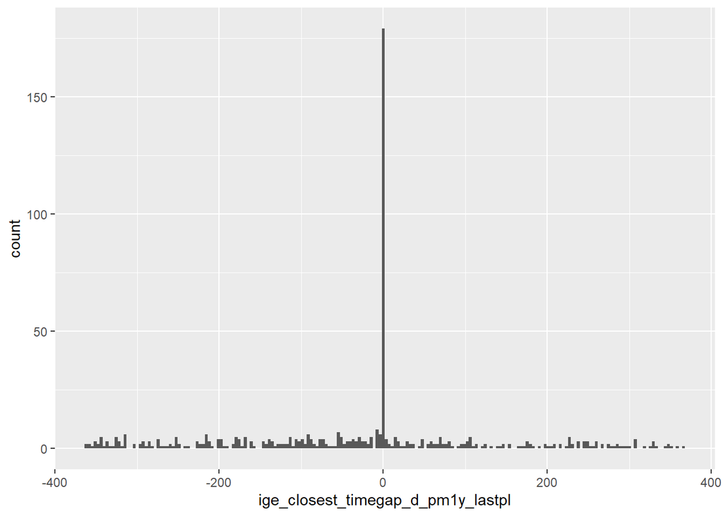

```r
ggplot(pool) + geom_histogram(aes(x = ige_closest_timegap_d_pm1y_lastpl), bins = 200)
```

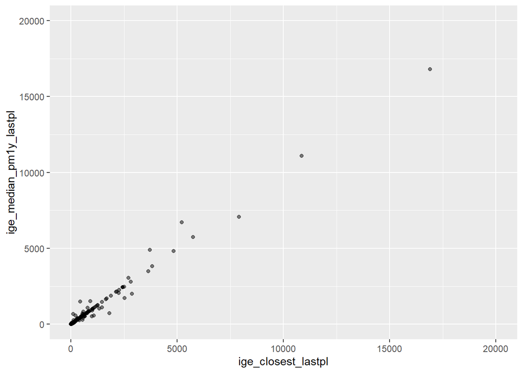

```r
ggplot(pool, aes(x = ige_closest_lastpl, y = ige_median_pm1y_lastpl)) +
        geom_point(alpha = 0.5) +
        xlim(0, 20000) + ylim(0, 20000)
```

### 4.4.3. IgE within (+/-)2 years of last plasma date

```r
## Generate variables on ige records from within (+/-)2 years of last plasma date

pool <- ige_vars_fnc(restriction = "abs(lab_timegap_y) <= 2", varname_suffix = "_pm2y_lastpl")


## Check median ige from within (+/-)2 years against ige closest to last plasma date

pool[, .N, .(has_ige_closest_lastpl, has_ige_rec_pm2y_lastpl)]
```

```
##    has_ige_closest_lastpl has_ige_rec_pm2y_lastpl    N
## 1:                      0                       0 7096
## 2:                      1                       1  790
## 3:                      1                       0  880
```

```r
pool[, summary(ige_closest_timegap_d_pm2y_lastpl)]
```

```
##    Min. 1st Qu.  Median    Mean 3rd Qu.    Max.    NA's
## -729.00 -226.00    0.00  -43.92   72.00  722.00    7976
```

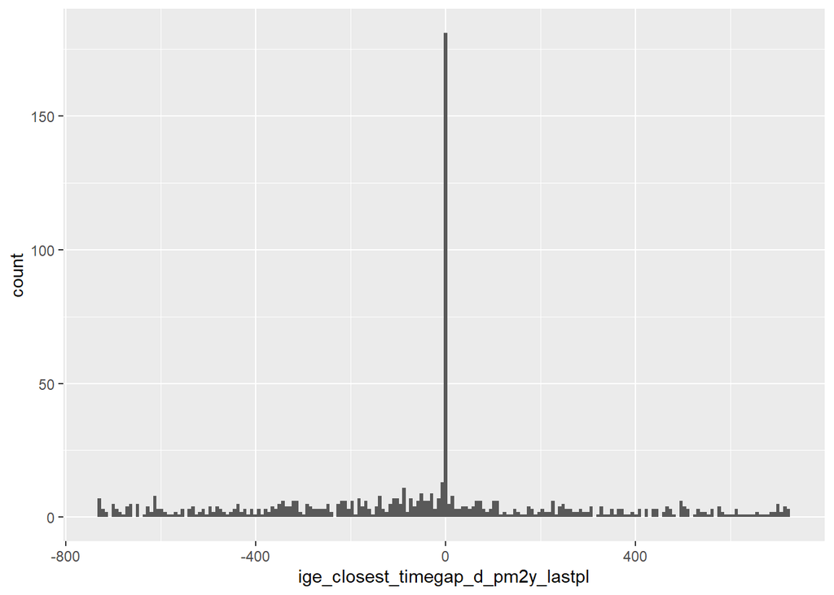

```r
ggplot(pool) + geom_histogram(aes(x = ige_closest_timegap_d_pm2y_lastpl), bins = 200)
```

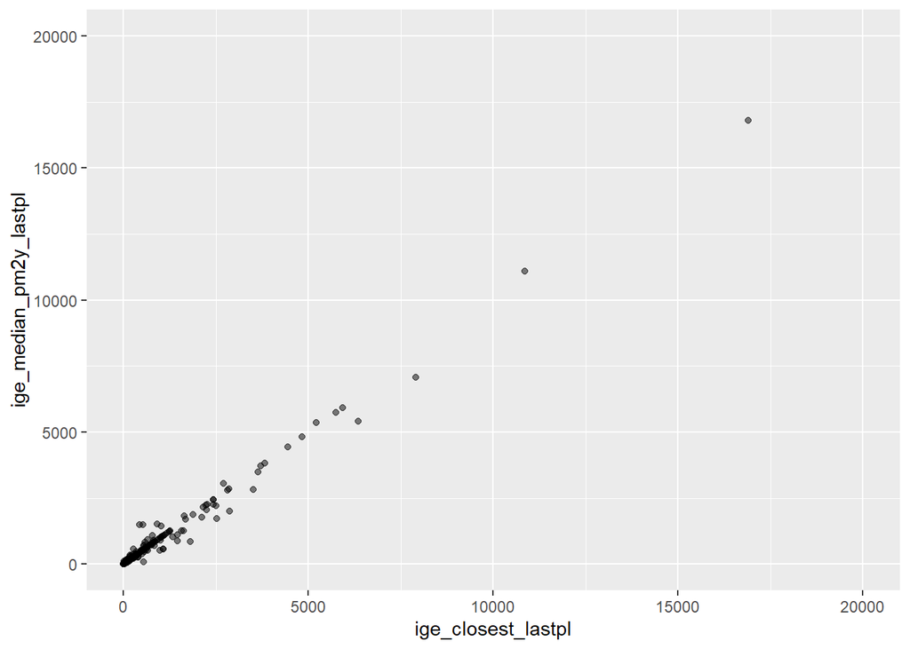

```r
ggplot(pool, aes(x = ige_closest_lastpl, y = ige_median_pm2y_lastpl)) +
        geom_point(alpha = 0.5) +
        xlim(0, 20000) + ylim(0, 20000)
```

### 4.4.4. IgE within (+/-)3 years of last plasma date

```r
## Generate variables on ige records from within (+/-)3 years of last plasma date

pool <- ige_vars_fnc(restriction = "abs(lab_timegap_y) <= 3", varname_suffix = "_pm3y_lastpl")


## Check median ige from within (+/-)3 years against ige closest to last plasma date

pool[, .N, .(has_ige_closest_lastpl, has_ige_rec_pm3y_lastpl)]
```

```
##    has_ige_closest_lastpl has_ige_rec_pm3y_lastpl    N
## 1:                      0                       0 7096
## 2:                      1                       1  960
## 3:                      1                       0  710
```

```r
pool[, summary(ige_closest_timegap_d_pm3y_lastpl)]
```

```
##     Min.  1st Qu.   Median     Mean  3rd Qu.     Max.     NA's
## -1094.00  -329.50     0.00   -48.83   174.50  1094.00     7806
```

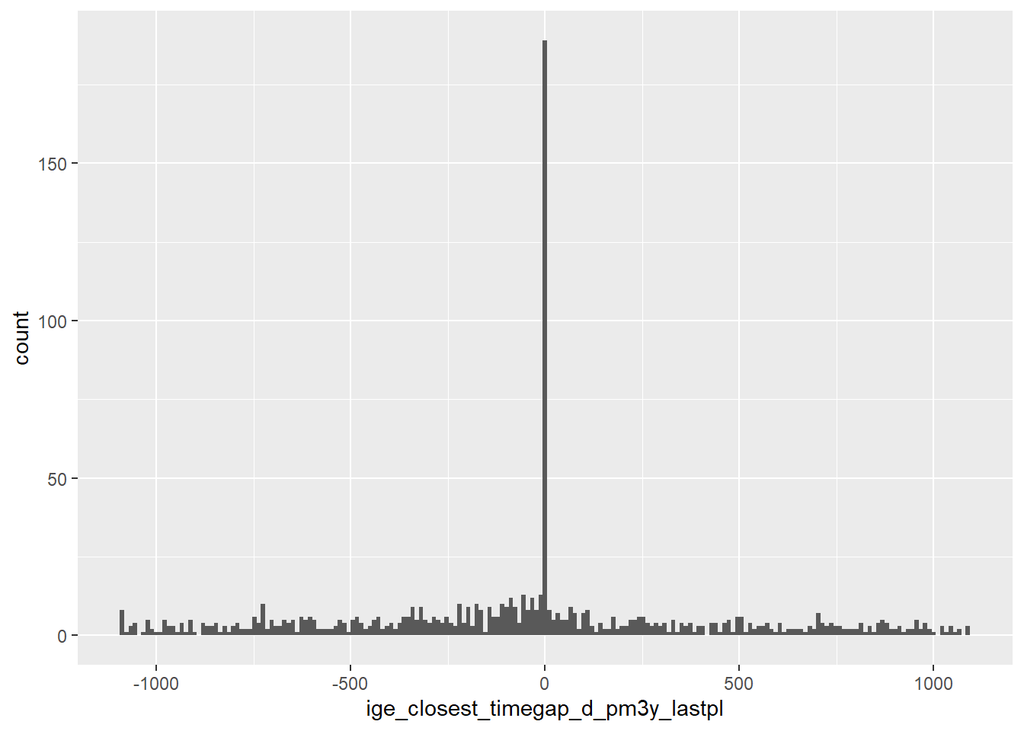

```r
ggplot(pool) + geom_histogram(aes(x = ige_closest_timegap_d_pm3y_lastpl), bins = 200)
```

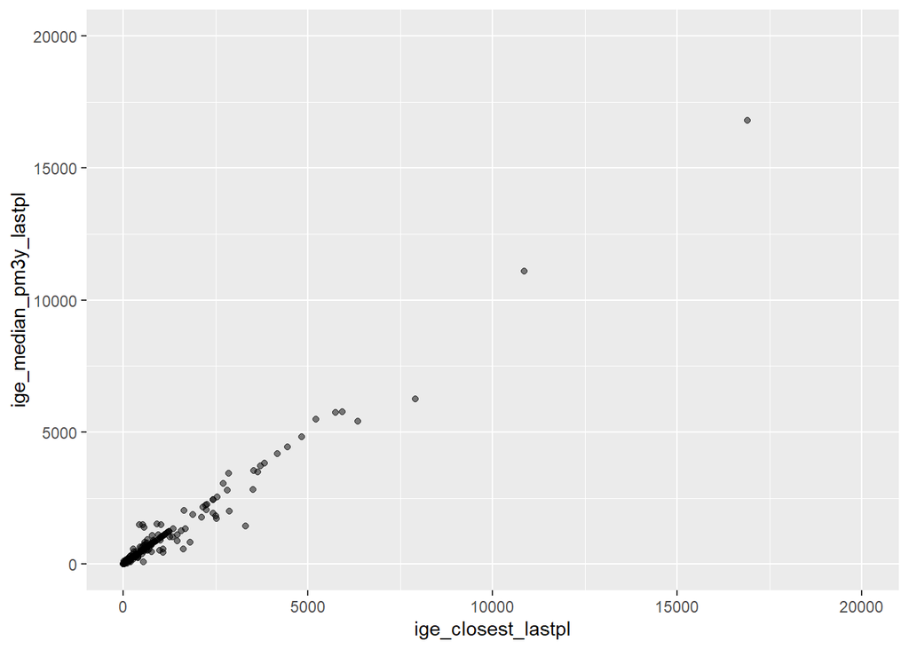

```r
ggplot(pool, aes(x = ige_closest_lastpl, y = ige_median_pm3y_lastpl)) +
        geom_point(alpha = 0.5) +
        xlim(0, 20000) + ylim(0, 20000)
```

# 5. Save selection pool data

```r
fwrite(pool, here(res_dir, "selection_pool.csv"))
```